# Full Data - Pinellas County Model Capstone

Housing Prices, Property Characteristics, and Spatial Dependence

Author

Hunter Evans

Published

November 9, 2026

# Project overview

This project models Pinellas County housing prices using a full complete-case analytic dataset.

Three modeling tiers are estimated:

1. OLS Hedonic Baseline
2. Bayesian Hierarchical Municipality Model using INLA
3. Bayesian Spatial SPDE Model using INLA

The primary spatial model uses an INLA Matern SPDE spatial field rather than constructing a CAR adjacency matrix across every individual property coordinate. This preserves the full property-level dataset while keeping the latent spatial model sparse and computationally tractable.

# 0. Packages and data import

```r
# SECTION 0: PACKAGES AND DATA IMPORT

required_packages <- c(
  "tidyverse",
  "janitor",
  "lubridate",
  "sf",
  "sp",
  "INLA",
  "ggplot2",
  "scales",
  "patchwork",
  "broom",
  "knitr",
  "viridis",
  "viridisLite"
)

# Install packages from CRAN
cran_packages <- setdiff(
  required_packages,
  rownames(installed.packages())
)

cran_packages <- setdiff(cran_packages, "INLA")

if (length(cran_packages) > 0) {
  install.packages(
    cran_packages,
    dependencies = TRUE
  )
}

# ---- 0.2 Install INLA if missing ----
# This uses the Windows binary repository for R 4.5.

if (!requireNamespace("INLA", quietly = TRUE)) {

  install.packages(
    "INLA",
    repos = c(
      getOption("repos"),
      INLA = "https://inla.r-inla-download.org/R/stable"
    ),
    dependencies = TRUE
  )
}

library(tidyverse)
library(janitor)
library(lubridate)
library(sf)
library(sp)
library(INLA)
library(ggplot2)
library(scales)
library(patchwork)
library(broom)
library(knitr)
library(viridis)
library(viridisLite)


analysis_version <- "pinellas_full_data_capstone_inla_spde_v1"


data_path <- paste0(
  "G:/",
  ".shortcut-targets-by-id/1IwJJwifiMkxN1ZtZ-lx4TooG6WGbO18w/",
  "Alderfer and Evans/1-data/pinellasdata.csv"
)

# Confirm that the file exists before importing
if (!file.exists(data_path)) {
  stop(
    paste0(
      "DATA FILE NOT FOUND.\n",
      "Check that the Google Drive location is available.\n",
      "Current path: ",
      data_path
    )
  )
}

required_17_columns <- c(
  "uid",
  "parcelid",
  "sale_year",
  "adj_price",
  "heated_area",
  "acreage",
  "stories",
  "quality",
  "foundation",
  "seawall",
  "cccl_distance",
  "tb_distance",
  "icw_distance",
  "frontage",
  "x_coord",
  "y_coord",
  "site_city"
)

# ---- 0.7 Import the full dataset ----
# Import as character first to avoid accidental type conversion.
# Numeric conversion will happen during the cleaning section.

raw_data <- readr::read_csv(
  file = data_path,
  col_select = tidyselect::all_of(required_17_columns),
  col_types = readr::cols(
    .default = readr::col_character()
  ),
  na = c(
    "",
    "NA",
    "N/A",
    ".",
    "null",
    "NULL",
    "*"
  ),
  progress = TRUE,
  show_col_types = FALSE
)
```

[output not shown]

```r
# ---- 0.8 Verify imported dataset ----

# Import verification

import_summary <- tibble(
  Check = c(
    "File exists",
    "Data object class",
    "Observations imported",
    "Variables imported"
  ),
  Result = c(
    file.exists(data_path),
    paste(class(raw_data), collapse = ", "),
    format(nrow(raw_data), big.mark = ","),
    ncol(raw_data)
  )
)

knitr::kable(import_summary, caption = "Data Import Verification")
```

Data Import Verification

| Check | Result |
| --- | --- |
| File exists | TRUE |
| Data object class | spec_tbl_df, tbl_df, tbl, data.frame |
| Observations imported | 267,074 |
| Variables imported | 17 |

```r
# Missing values by column

missing_summary <- tibble(Variable = names(raw_data), Missing = colSums(is.na(raw_data))) %>%
  arrange(desc(Missing))

knitr::kable(missing_summary, caption = "Missing Values by Variable")
```

Missing Values by Variable

| Variable | Missing |
| --- | --- |
| site_city | 3461 |
| uid | 0 |
| parcelid | 0 |
| sale_year | 0 |
| adj_price | 0 |
| heated_area | 0 |
| acreage | 0 |
| stories | 0 |
| quality | 0 |
| foundation | 0 |
| seawall | 0 |
| cccl_distance | 0 |
| tb_distance | 0 |
| icw_distance | 0 |
| frontage | 0 |
| x_coord | 0 |
| y_coord | 0 |

```r
# ---- 0.9 Stop if the import does not match expectations ----

if (!is.data.frame(raw_data)) {
  stop("Import failed: raw_data is not a data frame.")
}

if (ncol(raw_data) != 17) {
  stop(
    paste(
      "Expected 17 columns but imported",
      ncol(raw_data)
    )
  )
}

if (!all(required_17_columns %in% names(raw_data))) {
  stop("One or more required columns are missing.")
}

if (nrow(raw_data) == 0) {
  stop("The imported dataset contains zero rows.")
}
```

# 1. Clean data and construct predictors

```r
# 1. CLEANING AND VARIABLE CONSTRUCTION


df_clean <- raw_data %>%
  mutate(
    sale_year =
      parse_number(sale_year),

    sale_year_c =
      sale_year - 2000,

    adj_price =
      parse_number(adj_price),

    heated_area =
      parse_number(heated_area),

    acreage =
      parse_number(acreage),

    cccl_distance =
      parse_number(cccl_distance),

    tb_distance =
      parse_number(tb_distance),

    icw_distance =
      parse_number(icw_distance),

    x_coord =
      parse_number(x_coord),

    y_coord =
      parse_number(y_coord),
    frontage_raw =
      str_squish(
        str_to_upper(frontage)
      ),

    seawall_raw =
      str_squish(
        str_to_upper(seawall)
      ),

    quality_raw =
      str_squish(
        str_to_upper(quality)
      ),

    foundation_raw =
      str_squish(
        str_to_upper(foundation)
      ),

    site_city =
      str_squish(site_city),
    frontage_group = case_when(

      is.na(frontage_raw) ~
        NA_character_,

      frontage_raw %in% c(
        "NONE",
        "NO",
        "NO FRONTAGE",
        "NO FRONT"
      ) ~
        "None",

      str_detect(
        frontage_raw,
        "BAY|TAMPA BAY"
      ) ~
        "Bay",

      str_detect(
        frontage_raw,
        "LAKE|POND"
      ) ~
        "Lake",

      TRUE ~
        "Other"
    ),
    seawall_group = case_when(

      is.na(seawall_raw) ~
        NA_character_,

      str_detect(
        seawall_raw,
        "NO SEAWALL|^NO|N|FALSE|^0|NONE"
      ) ~
        "No",

      str_detect(
        seawall_raw,
        "^YES|Y|TRUE|^1$|HAS SEAWALL|SEAWALL"
      ) ~
        "Yes",

      TRUE ~
        NA_character_
    ),
    quality_group = case_when(

      is.na(quality_raw) ~
        NA_character_,

      str_detect(
        quality_raw,
        "ABOVE\\s*AVERAGE|SUPERIOR|EXCELLENT"
      ) ~
        "Above Average",

      str_detect(
        quality_raw,
        "MINIMAL|FAIR"
      ) ~
        "Fair",

      str_detect(
        quality_raw,
        "AVERAGE"
      ) ~
        "Average",

      TRUE ~
        NA_character_
    ),
    foundation_group = case_when(

      is.na(foundation_raw) ~
        NA_character_,

      str_detect(
        foundation_raw,
        "CONTINUOUS"
      ) ~
        "Yes",

      TRUE ~
        "No"
    ),
    stories_num =
      parse_number(stories),

    stories_group = case_when(

      is.na(stories_num) ~
        NA_character_,

      stories_num == 1 ~
        "1",

      stories_num == 2 ~
        "2",

      stories_num >= 3 ~
        "3+",

      TRUE ~
        NA_character_
    ),
    barrier_municipality = if_else(

      str_to_upper(site_city) %in% c(
        "ST PETE BEACH",
        "TREASURE ISLAND",
        "MADEIRA BEACH",
        "INDIAN ROCKS BEACH",
        "REDINGTON SHORES",
        "BELLEAIR BEACH",
        "REDINGTON BEACH",
        "NORTH REDINGTON BEACH",
        "INDIAN SHORES",
        "CLEARWATER BEACH"
      ),

      "Barrier",

      "Non-Barrier",

      missing = NA_character_
    ),
    log_price = if_else(
      !is.na(adj_price) &
        adj_price > 0,
      log(adj_price),
      NA_real_
    )
  ) %>%
  filter(

    sale_year >= 2000,

    sale_year <= 2015,

    !is.na(log_price),

    heated_area > 200,

    !is.na(x_coord),

    !is.na(y_coord),

    !is.na(site_city)
  )


# Variables required for complete-case modeling


model_vars <- c(
  "log_price",
  "sale_year_c",
  "frontage_group",
  "seawall_group",
  "cccl_distance",
  "tb_distance",
  "quality_group",
  "heated_area",
  "acreage",
  "site_city",
  "barrier_municipality",
  "stories_group",
  "foundation_group",
  "x_coord",
  "y_coord"
)


# Complete-case analytic dataset


model_data <- df_clean %>%

  filter(
    if_all(
      all_of(model_vars),
      ~ !is.na(.x)
    )
  ) %>%

  mutate(

    frontage_group =
      factor(
        frontage_group,
        levels = c(
          "None",
          "Lake",
          "Bay",
          "Other"
        )
      ),

    seawall_group =
      factor(
        seawall_group,
        levels = c(
          "No",
          "Yes"
        )
      ),

    quality_group =
      factor(
        quality_group,
        levels = c(
          "Average",
          "Fair",
          "Above Average"
        )
      ),

    foundation_group =
      factor(
        foundation_group,
        levels = c(
          "No",
          "Yes"
        )
      ),

    stories_group =
      factor(
        stories_group,
        levels = c(
          "1",
          "2",
          "3+"
        )
      ),

    barrier_municipality =
      factor(
        barrier_municipality,
        levels = c(
          "Non-Barrier",
          "Barrier"
        )
      ),

    site_city =
      factor(site_city)
  ) %>%

  droplevels() %>%

  mutate(

    frontage_group =
      relevel(
        frontage_group,
        ref = "None"
      ),

    seawall_group =
      relevel(
        seawall_group,
        ref = "No"
      ),

    quality_group =
      relevel(
        quality_group,
        ref = "Average"
      ),

    foundation_group =
      relevel(
        foundation_group,
        ref = "No"
      ),

    stories_group =
      relevel(
        stories_group,
        ref = "1"
      ),

    barrier_municipality =
      relevel(
        barrier_municipality,
        ref = "Non-Barrier"
      )
  )

rownames(model_data) <- NULL

cleaning_summary <- tibble(
  Stage = c(
    "After initial filters",
    "Final complete-case dataset"
  ),
  Observations = c(
    nrow(df_clean),
    nrow(model_data)
  ),
  Municipalities = c(
    NA_integer_,
    nlevels(model_data$site_city)
  )
)

knitr::kable(
  cleaning_summary,
  caption = "Data Cleaning and Sample Selection"
)
```

Data Cleaning and Sample Selection

| Stage | Observations | Municipalities |
| --- | --- | --- |
| After initial filters | 245477 | NA |
| Final complete-case dataset | 245477 | 27 |

# 2. Prepare Bayesian/INLA data

```r
# 2. BAYESIAN / INLA DATA


bayes_data <- model_data %>%

  mutate(

    # --------------------------------------------------------
    # Standardized continuous predictors
    # --------------------------------------------------------

    cccl_distance_b =
      as.numeric(
        scale(cccl_distance)
      ),

    tb_distance_b =
      as.numeric(
        scale(tb_distance)
      ),

    heated_area_b =
      as.numeric(
        scale(heated_area)
      ),

    acreage_b =
      as.numeric(
        scale(acreage)
      )
  )


# Municipality integer index for INLA


bayes_data$city_id <-
  as.integer(
    bayes_data$site_city
  )

bayesian_data_summary <- tibble(
  Metric = c(
    "Observations entering INLA",
    "Municipalities entering INLA"
  ),
  Value = c(
    nrow(bayes_data),
    nlevels(bayes_data$site_city)
  )
)

knitr::kable(
  bayesian_data_summary,
  caption = "Bayesian Modeling Dataset"
)
```

Bayesian Modeling Dataset

| Metric | Value |
| --- | --- |
| Observations entering INLA | 245477 |
| Municipalities entering INLA | 27 |

# 3. Observation-count summary

```r
# 3. DATA SUMMARY


eda_sample_summary <- tibble(

  Stage = c(
    "Raw input",
    "After initial filters",
    "Final complete-case analytic dataset"
  ),

  Observations = c(
    nrow(raw_data),
    nrow(df_clean),
    nrow(model_data)
  )
)

knitr::kable(
  eda_sample_summary,
  caption =
    "Observation counts through data preparation"
)
```

Observation counts through data preparation

| Stage | Observations |
| --- | --- |
| Raw input | 267074 |
| After initial filters | 245477 |
| Final complete-case analytic dataset | 245477 |

# 4. Exploratory data analysis

## 4.1 Distribution of log adjusted price

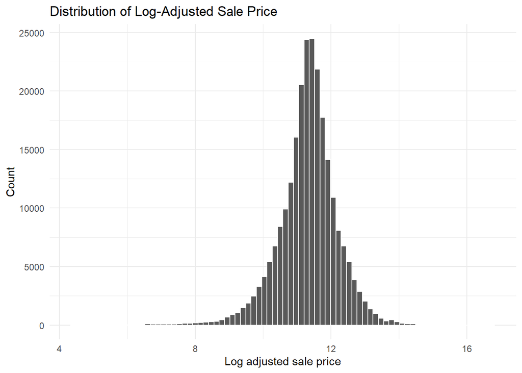

```r
# EDA 1: LOG PRICE

ggplot(model_data, aes(x = log_price)) +
  geom_histogram(bins = 80, color = "white") +
  labs(title = "Distribution of Log-Adjusted Sale Price", x = "Log adjusted sale price", y = "Count") +
  theme_minimal()
```

## 4.2 Distribution of adjusted price

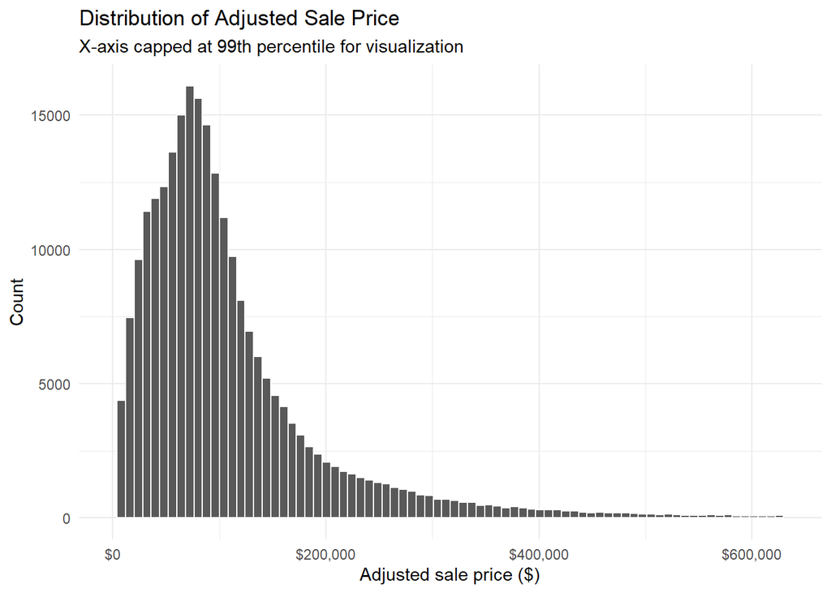

```r
# EDA 2: RAW PRICE

price_cap <- quantile(model_data$adj_price, 0.99, na.rm = TRUE)

ggplot(model_data, aes(x = adj_price)) +
  geom_histogram(bins = 80, color = "white") +
  scale_x_continuous(labels = scales::dollar, limits = c(0, price_cap)) +
  labs(title = "Distribution of Adjusted Sale Price", subtitle = "X-axis capped at 99th percentile for visualization", x = "Adjusted sale price ($)", y = "Count") +
  theme_minimal()
```

## 4.3 Sales volume by year

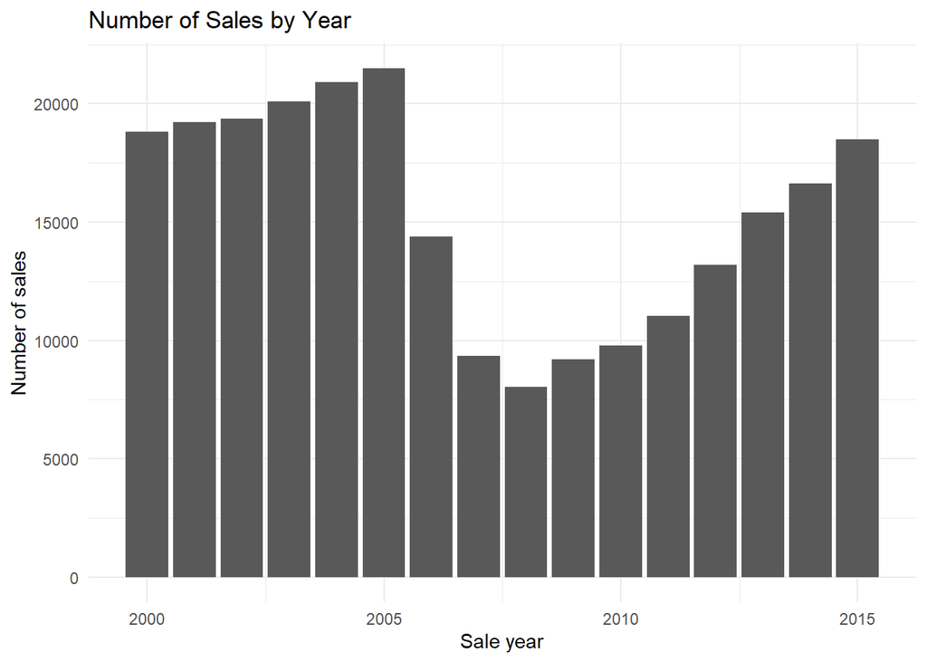

```r
# EDA 3: SALES BY YEAR

model_data %>%
  count(sale_year) %>%
  ggplot(aes(x = sale_year, y = n)) +
  geom_col() +
  labs(title = "Number of Sales by Year", x = "Sale year", y = "Number of sales") +
  theme_minimal()
```

## 4.4 Log price versus sale year

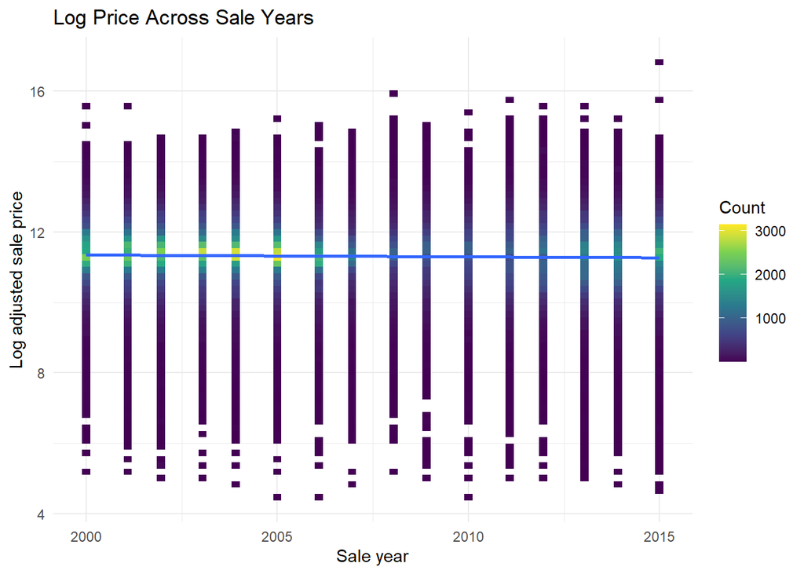

```r
# EDA 4: YEAR VS PRICE

ggplot(model_data, aes(x = sale_year, y = log_price)) +
  geom_bin2d(bins = 70) +
  scale_fill_viridis_c() +
  geom_smooth(method = "lm", se = TRUE) +
  labs(title = "Log Price Across Sale Years", x = "Sale year", y = "Log adjusted sale price", fill = "Count") +
  theme_minimal()
```

## 4.5 Price by frontage

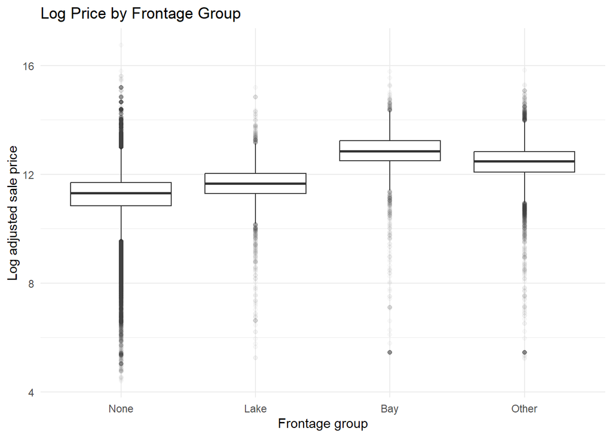

```r
# EDA 5: FRONTAGE

ggplot(model_data, aes(x = frontage_group, y = log_price)) +
  geom_boxplot(outlier.alpha = 0.03) +
  labs(title = "Log Price by Frontage Group", x = "Frontage group", y = "Log adjusted sale price") +
  theme_minimal()
```

## 4.6 Price by quality

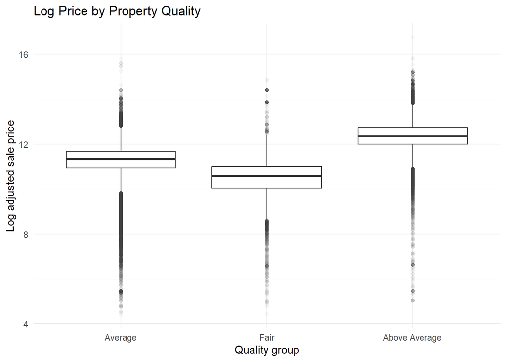

```r
# EDA 6: QUALITY

ggplot(model_data, aes(x = quality_group, y = log_price)) +
  geom_boxplot(outlier.alpha = 0.03) +
  labs(title = "Log Price by Property Quality", x = "Quality group", y = "Log adjusted sale price") +
  theme_minimal()
```

## 4.7 Price by seawall

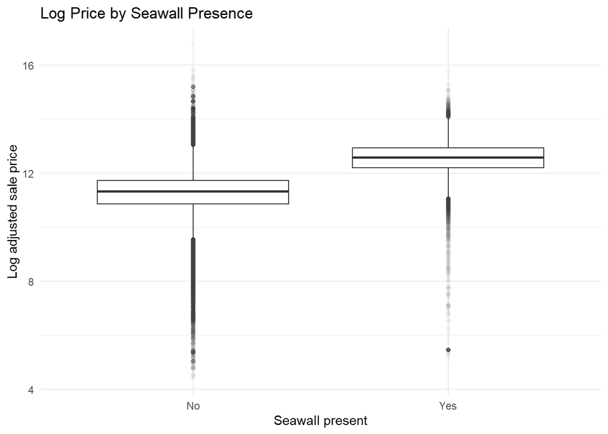

```r
# EDA 7: SEAWALL

ggplot(model_data, aes(x = seawall_group, y = log_price)) +
  geom_boxplot(outlier.alpha = 0.03) +
  labs(title = "Log Price by Seawall Presence", x = "Seawall present", y = "Log adjusted sale price") +
  theme_minimal()
```

## 4.8 Price by stories

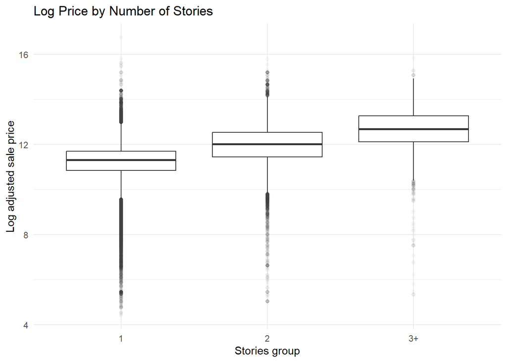

```r
# EDA 8: STORIES

ggplot(model_data, aes(x = stories_group, y = log_price)) +
  geom_boxplot(outlier.alpha = 0.03) +
  labs(title = "Log Price by Number of Stories", x = "Stories group", y = "Log adjusted sale price") +
  theme_minimal()
```

## 4.9 Price by foundation

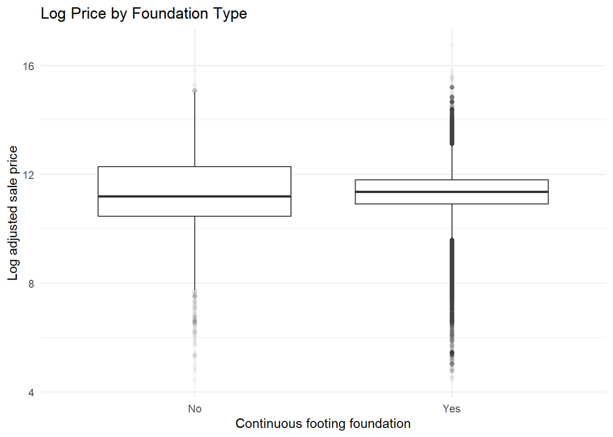

```r
# EDA 9: FOUNDATION

ggplot(model_data, aes(x = foundation_group, y = log_price)) +
  geom_boxplot(outlier.alpha = 0.03) +
  labs(title = "Log Price by Foundation Type", x = "Continuous footing foundation", y = "Log adjusted sale price") +
  theme_minimal()
```

## 4.10 Price by barrier municipality

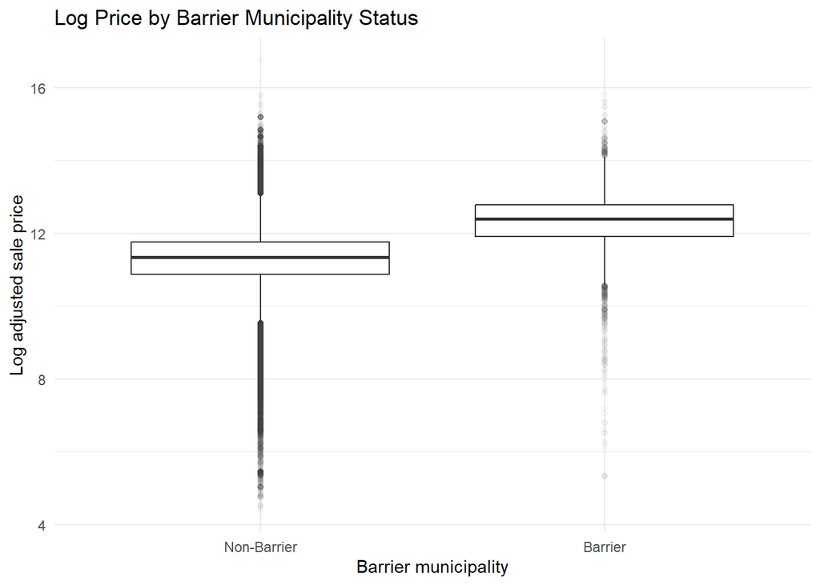

```r
# EDA 10: BARRIER STATUS

ggplot(model_data,aes(x = barrier_municipality, y = log_price)) +
  geom_boxplot(outlier.alpha = 0.03) +
labs(title = "Log Price by Barrier Municipality Status", x = "Barrier municipality", y = "Log adjusted sale price") +
theme_minimal()
```

## 4.11 Categorical predictor frequencies

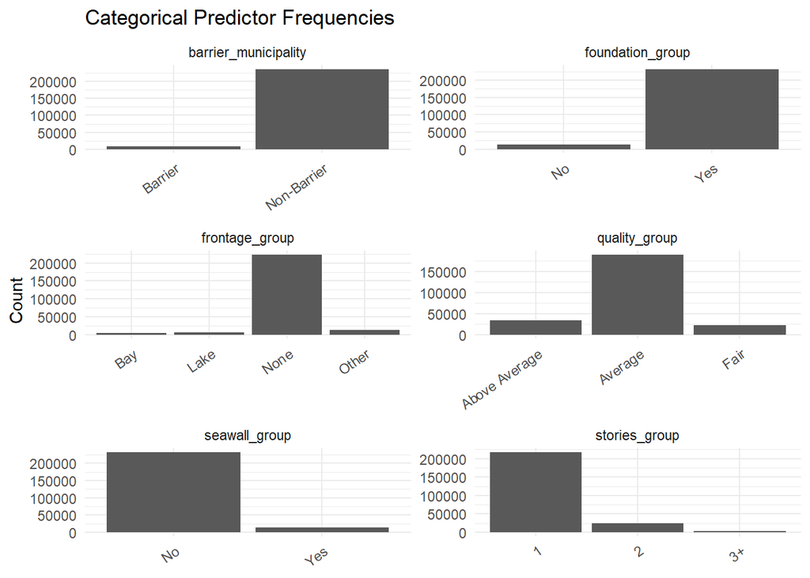

```r
# EDA 11: CATEGORICAL FREQUENCIES

cat_data_long <- model_data %>%
  select(
    frontage_group,
    seawall_group,
    quality_group,
    barrier_municipality,
    stories_group,
    foundation_group
  ) %>%
  mutate(across(everything(), as.character)) %>%
  pivot_longer(
    everything(),
    names_to = "Variable",
    values_to = "Category"
  ) %>%
  count(Variable, Category)

ggplot(
  cat_data_long,
  aes(x = Category, y = n)
) +
  geom_col() +
  facet_wrap(
    ~ Variable,
    scales = "free",
    ncol = 2) +
  labs(
    title = "Categorical Predictor Frequencies",
    x = NULL,
    y = "Count"
  ) +
  theme_minimal() +
  theme(
    axis.text.x = element_text(
      angle = 35,
      hjust = 1
    )
  )
```

## 4.12 Continuous predictor distributions

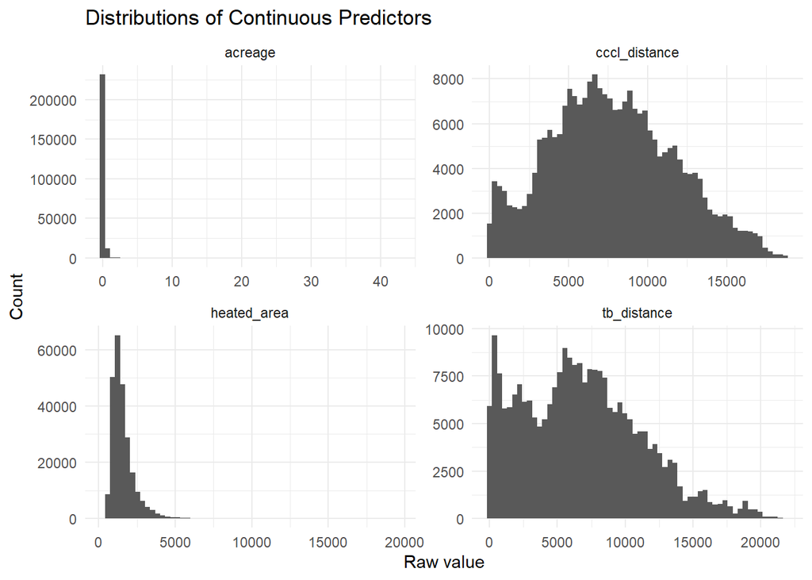

```r
# EDA 12: CONTINUOUS VARIABLES

cont_data_long <- model_data %>%
  select(
    cccl_distance,
    tb_distance,
    heated_area,
    acreage
  ) %>%
  pivot_longer(
    everything(),
    names_to = "Variable",
    values_to = "Value"
  )

ggplot(
  cont_data_long,
  aes(x = Value)
) +
  geom_histogram(bins = 60) +
  facet_wrap(
    ~ Variable,
    scales = "free",
    ncol = 2
  ) +
  labs(
    title = "Distributions of Continuous Predictors",
    x = "Raw value",
    y = "Count"
  ) +
  theme_minimal()
```

## 4.13 Heated area versus price

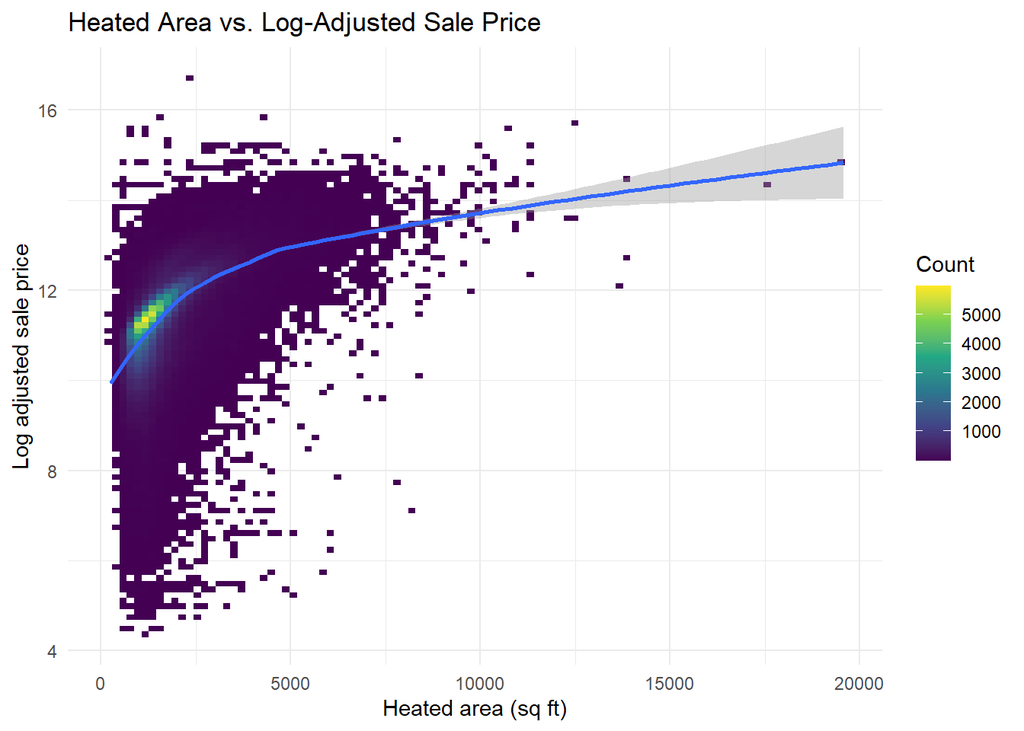

```r
# EDA 13: HEATED AREA VS PRICE

ggplot(
  model_data,
  aes(x = heated_area, y = log_price)
) +
  geom_bin2d(bins = 100) +
  scale_fill_viridis_c() +
  geom_smooth(
    method = "gam",
    se = TRUE
  ) +
  labs(
    title = "Heated Area vs. Log-Adjusted Sale Price",
    x = "Heated area (sq ft)",
    y = "Log adjusted sale price",
    fill = "Count"
  ) +
  theme_minimal()
```

## 4.14 Mean price by municipality

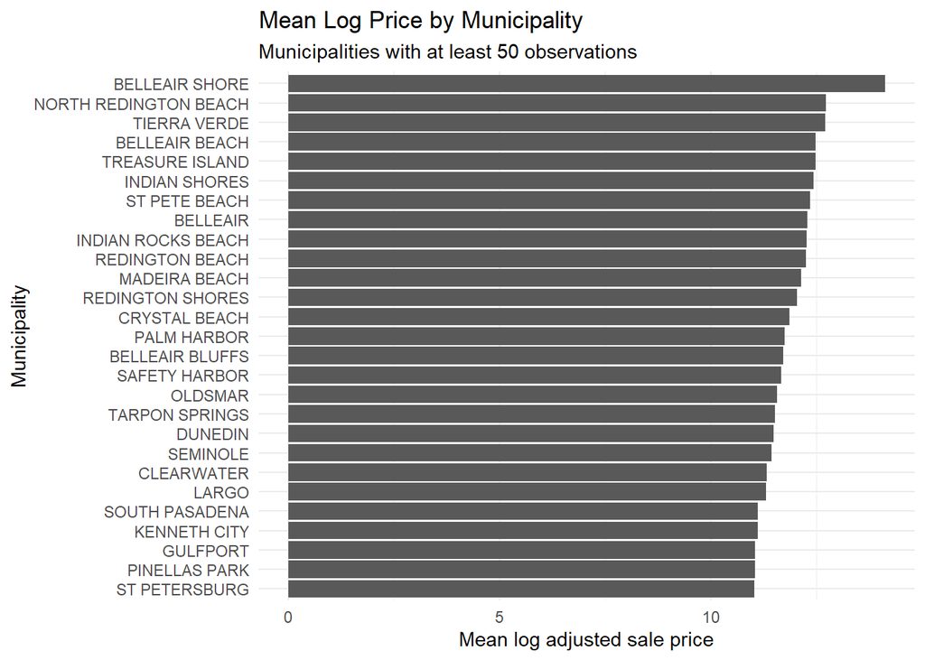

```r
# EDA 14: MUNICIPALITY PRICE

city_summary <- model_data %>%
  group_by(site_city) %>%
  summarise(
    mean_log_price = mean(log_price, na.rm = TRUE),
    count = n(),
    .groups = "drop"
  ) %>%
  filter(count >= 50) %>%
  arrange(desc(mean_log_price))

ggplot(
  city_summary,
  aes(
    x = reorder(site_city, mean_log_price),
    y = mean_log_price
  )
) +
  geom_col() +
  coord_flip() +
  labs(
    title = "Mean Log Price by Municipality",
    subtitle = "Municipalities with at least 50 observations",
    x = "Municipality",
    y = "Mean log adjusted sale price"
  ) +
  theme_minimal()
```

## 4.15 Geographic distribution

Only the visualization is sampled. The model uses all observations.

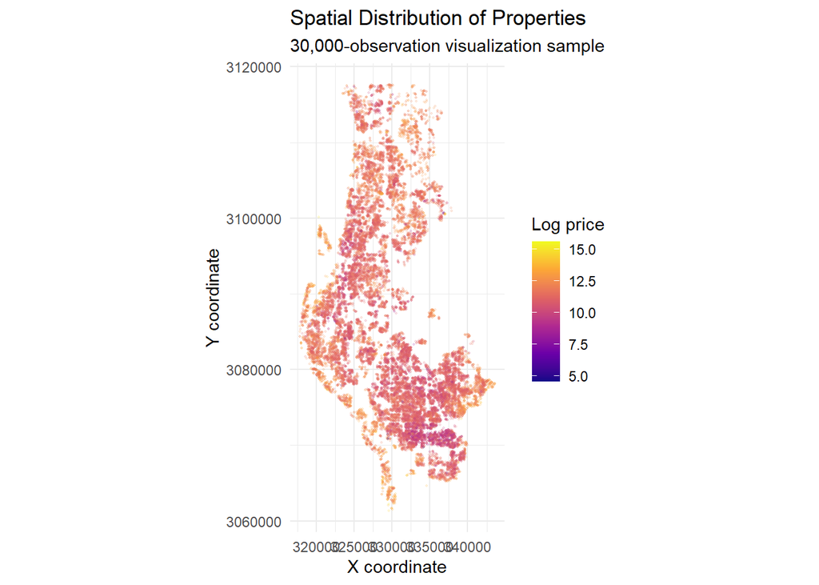

```r
# EDA 15: SPATIAL DISTRIBUTION

set.seed(12345)

eda_map_n <- min(30000L, nrow(model_data))

eda_map_sample <- sample(
  seq_len(nrow(model_data)),
  size = eda_map_n
)

eda_map_data <- model_data[eda_map_sample, ]

ggplot(
  eda_map_data,
  aes(x = x_coord, y = y_coord, color = log_price)
) +
  geom_point(alpha = 0.15, size = 0.3) +
  scale_color_viridis_c(option = "plasma") +
  coord_equal() +
  labs(
    title = "Spatial Distribution of Properties",
    subtitle = "30,000-observation visualization sample",
    x = "X coordinate",
    y = "Y coordinate",
    color = "Log price"
  ) +
  theme_minimal()
```

# 5. Model 1 — OLS hedonic baseline

```r
# 5. OLS HEDONIC BASELINE

hedonic_formula <- log_price ~
  sale_year_c +
  frontage_group +
  seawall_group +
  cccl_distance +
  tb_distance +
  quality_group +
  heated_area +
  acreage +
  barrier_municipality +
  stories_group +
  foundation_group

ols_model <- lm(
  formula = hedonic_formula,
  data = model_data
)

summary(ols_model)
```

```
Call:
lm(formula = hedonic_formula, data = model_data)

Residuals:
    Min      1Q  Median      3Q     Max
-8.1762 -0.2075  0.1620  0.3811  4.7581

Coefficients:
                              Estimate Std. Error  t value Pr(>|t|)
(Intercept)                  1.030e+01  9.386e-03 1097.083   <2e-16 ***
sale_year_c                 -4.068e-03  2.844e-04  -14.306   <2e-16 ***
frontage_groupLake           1.225e-01  9.630e-03   12.719   <2e-16 ***
frontage_groupBay            2.720e-01  1.534e-02   17.732   <2e-16 ***
frontage_groupOther          3.335e-01  1.046e-02   31.886   <2e-16 ***
seawall_groupYes             2.816e-01  1.127e-02   24.989   <2e-16 ***
cccl_distance                5.371e-06  4.428e-07   12.131   <2e-16 ***
tb_distance                  1.512e-05  3.789e-07   39.908   <2e-16 ***
quality_groupFair           -4.882e-01  5.170e-03  -94.426   <2e-16 ***
quality_groupAbove Average   2.980e-01  5.656e-03   52.680   <2e-16 ***
heated_area                  4.498e-04  2.871e-06  156.646   <2e-16 ***
acreage                      6.424e-02  6.997e-03    9.181   <2e-16 ***
barrier_municipalityBarrier  4.978e-01  8.836e-03   56.338   <2e-16 ***
stories_group2              -1.160e-01  5.521e-03  -21.014   <2e-16 ***
stories_group3+             -1.662e-01  1.445e-02  -11.501   <2e-16 ***
foundation_groupYes          1.398e-01  6.949e-03   20.123   <2e-16 ***
---
Signif. codes:  0 '***' 0.001 '**' 0.01 '*' 0.05 '.' 0.1 ' ' 1

Residual standard error: 0.6904 on 245461 degrees of freedom
Multiple R-squared:  0.402, Adjusted R-squared:  0.4019
F-statistic: 1.1e+04 on 15 and 245461 DF,  p-value: < 2.2e-16
```

```r
ols_fit <- tibble(
  Model = "OLS hedonic baseline",
  N = nobs(ols_model),
  R_squared = summary(ols_model)$r.squared,
  Adjusted_R_squared = summary(ols_model)$adj.r.squared,
  AIC = AIC(ols_model),
  BIC = BIC(ols_model),
  RMSE = sqrt(mean(residuals(ols_model)^2)),
  MAE = mean(abs(residuals(ols_model)))
)

ols_fit
```

| Model | N | R_squared | Adjusted_R_squared | AIC | BIC | RMSE | MAE |
| --- | --- | --- | --- | --- | --- | --- | --- |
| OLS hedonic baseline | 245477 | 0.4019507 | 0.4019141 | 514735.1 | 514912.1 | 0.6903413 | 0.4611369 |

# 6. Model 2 — INLA hierarchical municipality model

```r
# 6. INLA HIERARCHICAL MUNICIPALITY MODEL

city_formula <- log_price ~
  sale_year_c +
  frontage_group +
  seawall_group +
  cccl_distance_b +
  tb_distance_b +
  quality_group +
  heated_area_b +
  acreage_b +
  barrier_municipality +
  stories_group +
  foundation_group +
  f(city_id, model = "iid")

inla_city <- inla(
  formula = city_formula,
  family = "gaussian",
  data = bayes_data,
  control.predictor = list(
    compute = TRUE,
    link = 1
  ),
  control.compute = list(
    dic = TRUE,
    waic = TRUE,
    cpo = TRUE,
    return.marginals.predictor = TRUE
  ),
  control.inla = list(
    strategy = "simplified.laplace"
  ),
  verbose = FALSE
)

summary(inla_city)
```

```
Time used:
    Pre = 1.28, Running = 29.1, Post = 9.05, Total = 39.5
Fixed effects:
                              mean    sd 0.025quant 0.5quant 0.975quant   mode
(Intercept)                 11.318 0.062     11.196   11.318     11.440 11.318
sale_year_c                 -0.004 0.000     -0.004   -0.004     -0.003 -0.004
frontage_groupLake           0.092 0.010      0.073    0.092      0.110  0.092
frontage_groupBay            0.312 0.015      0.283    0.312      0.342  0.312
frontage_groupOther          0.318 0.010      0.298    0.318      0.338  0.318
seawall_groupYes             0.322 0.011      0.300    0.322      0.344  0.322
cccl_distance_b              0.125 0.003      0.119    0.125      0.130  0.125
tb_distance_b                0.130 0.004      0.123    0.130      0.137  0.130
quality_groupFair           -0.479 0.005     -0.489   -0.479     -0.469 -0.479
quality_groupAbove Average   0.268 0.006      0.257    0.268      0.279  0.268
heated_area_b                0.315 0.002      0.311    0.315      0.320  0.315
acreage_b                    0.015 0.002      0.012    0.015      0.018  0.015
barrier_municipalityBarrier  0.456 0.107      0.244    0.456      0.667  0.456
stories_group2              -0.071 0.005     -0.082   -0.071     -0.060 -0.071
stories_group3+             -0.119 0.014     -0.147   -0.119     -0.091 -0.119
foundation_groupYes          0.132 0.007      0.119    0.132      0.146  0.132
                            kld
(Intercept)                   0
sale_year_c                   0
frontage_groupLake            0
frontage_groupBay             0
frontage_groupOther           0
seawall_groupYes              0
cccl_distance_b               0
tb_distance_b                 0
quality_groupFair             0
quality_groupAbove Average    0
heated_area_b                 0
acreage_b                     0
barrier_municipalityBarrier   0
stories_group2                0
stories_group3+               0
foundation_groupYes           0

Random effects:
  Name    Model
    city_id IID model

Model hyperparameters:
                                         mean    sd 0.025quant 0.5quant
Precision for the Gaussian observations  2.17 0.006       2.16     2.17
Precision for city_id                   15.83 4.568       8.51    15.27
                                        0.975quant  mode
Precision for the Gaussian observations       2.18  2.17
Precision for city_id                        26.33 14.26

Deviance Information Criterion (DIC) ...............: 506325.88
Deviance Information Criterion (DIC, saturated) ....: 245515.05
Effective number of parameters .....................: 41.60

Watanabe-Akaike information criterion (WAIC) ...: 503197.18
Effective number of parameters .................: 57.79

Marginal log-Likelihood:  -253366.74
CPO, PIT is computed
Posterior summaries for the linear predictor and the fitted values are computed
(Posterior marginals needs also 'control.compute=list(return.marginals.predictor=TRUE)')
```

## 6.1 Municipality fixed effects

```r
# MUNICIPALITY MODEL FIXED EFFECTS

inla_city$summary.fixed
```

|  | mean | sd | 0.025quant | 0.5quant | 0.975quant | mode | kld |
| --- | --- | --- | --- | --- | --- | --- | --- |
| (Intercept) | 11.31767243 | 0.0620369526 | 11.195589991 | 11.31756000 | 11.440379494 | 11.31756046 | 2.078614e-08 |
| sale_year_c | -0.00383215 | 0.0002796029 | -0.004380424 | -0.00383215 | -0.003283876 | -0.00383215 | 5.472025e-11 |
| frontage_groupLake | 0.09171688 | 0.0095017501 | 0.073084881 | 0.09171688 | 0.110348888 | 0.09171688 | 5.471212e-11 |
| frontage_groupBay | 0.31230099 | 0.0151934531 | 0.282508118 | 0.31230099 | 0.342093872 | 0.31230099 | 5.469229e-11 |
| frontage_groupOther | 0.31817463 | 0.0103284688 | 0.297921513 | 0.31817463 | 0.338427749 | 0.31817463 | 5.470300e-11 |
| seawall_groupYes | 0.32179786 | 0.0111628656 | 0.299908572 | 0.32179785 | 0.343687149 | 0.32179785 | 5.476587e-11 |
| cccl_distance_b | 0.12453668 | 0.0028805743 | 0.118888209 | 0.12453666 | 0.130185259 | 0.12453666 | 5.477346e-11 |
| tb_distance_b | 0.12960457 | 0.0035223495 | 0.122697696 | 0.12960453 | 0.136511662 | 0.12960453 | 5.466872e-11 |
| quality_groupFair | -0.47914193 | 0.0051641343 | -0.489268298 | -0.47914193 | -0.469015572 | -0.47914193 | 5.437988e-11 |
| quality_groupAbove Average | 0.26771975 | 0.0056232595 | 0.256693091 | 0.26771975 | 0.278746415 | 0.26771975 | 5.485937e-11 |

[output cut: 6 more lines]

## 6.2 Municipality random effects

```r
# MUNICIPALITY RANDOM EFFECTS
inla_city$summary.random$city_id
```

| ID | mean | sd | 0.025quant | 0.5quant | 0.975quant | mode | kld |
| --- | --- | --- | --- | --- | --- | --- | --- |
| 1 | 0.368271261 | 0.06409707 | 0.24183299 | 0.368297158 | 0.494562566 | 0.368296409 | 2.242744e-08 |
| 2 | 0.116298201 | 0.08995444 | -0.06116700 | 0.116331478 | 0.293576676 | 0.116331025 | 2.216185e-08 |
| 3 | 0.238703948 | 0.06661515 | 0.10744082 | 0.238715179 | 0.369901772 | 0.238714490 | 2.266803e-08 |
| 4 | 0.546239560 | 0.10104414 | 0.35014488 | 0.545450550 | 0.746859381 | 0.545463452 | 1.757198e-08 |
| 5 | -0.024032962 | 0.06178717 | -0.14624101 | -0.023927289 | 0.097588305 | -0.023927730 | 2.041787e-08 |
| 6 | 0.116476106 | 0.06654722 | -0.01482997 | 0.116549679 | 0.247367154 | 0.116548591 | 2.278277e-08 |
| 7 | 0.024202070 | 0.06195582 | -0.09835172 | 0.024315502 | 0.146125796 | 0.024315044 | 2.068236e-08 |
| 8 | -0.105791027 | 0.06239335 | -0.22915871 | -0.105687936 | 0.017002795 | -0.105688524 | 2.120382e-08 |
| 9 | 0.023449668 | 0.08925323 | -0.15276044 | 0.023517962 | 0.199278915 | 0.023517541 | 2.180681e-08 |
| 10 | 0.410816421 | 0.10638415 | 0.20335136 | 0.410196222 | 0.621806836 | 0.410205435 | 2.195129e-08 |

[output cut: 17 more lines]

## 6.3 Municipality model fit statistics

```r
# MUNICIPALITY MODEL FIT

city_model_fit <- tibble(
  Model = "INLA municipality",
  N = nrow(bayes_data),
  DIC = inla_city$dic$dic,
  WAIC = inla_city$waic$waic
)

city_model_fit
```

| Model | N | DIC | WAIC |
| --- | --- | --- | --- |
| INLA municipality | 245477 | 506325.9 | 503197.2 |

# 7. Prepare projected spatial coordinates

Coordinates are projected UTM Zone 17N coordinates measured in meters. We are unsure whether the original datum is WGS 84 (EPSG:32617) or NAD83 (EPSG:26917).

```r
# 7. PREPARE PROJECTED SPATIAL COORDINATES
# Retain the supplied projected coordinates.
# Coordinates are consistent with UTM Zone 17N in meters.

projected_coords <-
  as.matrix(
    bayes_data[
      ,
      c("x_coord", "y_coord")
    ]
  )

colnames(projected_coords) <-
  c("x", "y")

# Verify coordinates.

stopifnot(
  nrow(projected_coords) == nrow(bayes_data),
  ncol(projected_coords) == 2,
  all(is.finite(projected_coords))
)


# Compare possible coordinate reference systems.


test_crs <- function(epsg_code, crs_name) {

  points <- st_as_sf(
    bayes_data,
    coords = c("x_coord", "y_coord"),
    crs = epsg_code
  )

  points_lonlat <- st_transform(
    points,
    4326
  )

  coords <- st_coordinates(points_lonlat)

  tibble(
    coordinate_system = crs_name,
    minimum_longitude = min(coords[, 1]),
    maximum_longitude = max(coords[, 1]),
    minimum_latitude = min(coords[, 2]),
    maximum_latitude = max(coords[, 2])
  )
}

crs_comparison <- bind_rows(

  test_crs(
    32617,
    "WGS 84 / UTM Zone 17N"
  ),

  test_crs(
    26917,
    "NAD83 / UTM Zone 17N"
  ),

  test_crs(
    2882,
    "NAD83(HARN) StatePlane Florida West (feet)"
  )

)


# Compare WGS 84 and NAD83 geographic locations.


coords_32617 <- st_coordinates(
  st_transform(
    st_as_sf(
      bayes_data,
      coords = c("x_coord", "y_coord"),
      crs = 32617
    ),
    4326
  )
)

coords_26917 <- st_coordinates(
  st_transform(
    st_as_sf(
      bayes_data,
      coords = c("x_coord", "y_coord"),
      crs = 26917
    ),
    4326
  )
)

longitude_difference <- max(
  abs(coords_32617[, 1] - coords_26917[, 1])
)

latitude_difference <- max(
  abs(coords_32617[, 2] - coords_26917[, 2])
)


# Combine results into one readable table.

coordinate_summary <-
  bind_rows(

    tibble(
      coordinate_system = "Original supplied coordinates",
      measurement = c(
        "Number of observations",
        "Minimum X",
        "Maximum X",
        "Minimum Y",
        "Maximum Y"
      ),
      value = c(
        nrow(projected_coords),
        min(projected_coords[, 1]),
        max(projected_coords[, 1]),
        min(projected_coords[, 2]),
        max(projected_coords[, 2])
      ),
      units = c(
        "observations",
        "meters",
        "meters",
        "meters",
        "meters"
      )
    ),

    crs_comparison %>%
      pivot_longer(
        cols = -coordinate_system,
        names_to = "measurement",
        values_to = "value"
      ) %>%
      mutate(
        measurement = recode(
          measurement,
          minimum_longitude = "Minimum longitude",
          maximum_longitude = "Maximum longitude",
          minimum_latitude = "Minimum latitude",
          maximum_latitude = "Maximum latitude"
        ),
        units = "decimal degrees"
      )

  )

knitr::kable(
  coordinate_summary,
  digits = 6,
  caption = "Spatial Coordinates and Coordinate Reference System Comparison",
  col.names = c(
    "Coordinate system",
    "Measurement",
    "Value",
    "Units"
  )
)
```

Spatial Coordinates and Coordinate Reference System Comparison

| Coordinate system | Measurement | Value | Units |
| --- | --- | --- | --- |
| Original supplied coordinates | Number of observations | 245477.00000 | observations |
| Original supplied coordinates | Minimum X | 317784.41270 | meters |
| Original supplied coordinates | Maximum X | 343618.70940 | meters |
| Original supplied coordinates | Minimum Y | 3061037.35000 | meters |
| Original supplied coordinates | Maximum Y | 3117629.43300 | meters |
| WGS 84 / UTM Zone 17N | Minimum longitude | -82.85109 | decimal degrees |
| WGS 84 / UTM Zone 17N | Maximum longitude | -82.58773 | decimal degrees |
| WGS 84 / UTM Zone 17N | Minimum latitude | 27.66277 | decimal degrees |
| WGS 84 / UTM Zone 17N | Maximum latitude | 28.17327 | decimal degrees |
| NAD83 / UTM Zone 17N | Minimum longitude | -82.85109 | decimal degrees |
| NAD83 / UTM Zone 17N | Maximum longitude | -82.58773 | decimal degrees |
| NAD83 / UTM Zone 17N | Minimum latitude | 27.66277 | decimal degrees |
| NAD83 / UTM Zone 17N | Maximum latitude | 28.17327 | decimal degrees |
| NAD83(HARN) StatePlane Florida West (feet) | Minimum longitude | -83.10140 | decimal degrees |
| NAD83(HARN) StatePlane Florida West (feet) | Maximum longitude | -83.01708 | decimal degrees |
| NAD83(HARN) StatePlane Florida West (feet) | Minimum latitude | 32.74774 | decimal degrees |
| NAD83(HARN) StatePlane Florida West (feet) | Maximum latitude | 32.90319 | decimal degrees |

```r
head(bayes_data[, c("x_coord", "y_coord")], 20)
```

| x_coord | y_coord |
| --- | --- |
| 328086.1 | 3117251 |
| 328144.9 | 3117321 |
| 328144.9 | 3117321 |
| 328190.5 | 3117352 |
| 328179.9 | 3117203 |
| 328179.9 | 3117203 |
| 328195.5 | 3116993 |
| 328195.5 | 3116993 |
| 328195.5 | 3116993 |
| 328195.3 | 3117025 |

[output cut: 10 more lines]

# 8. Construct computationally efficient INLA SPDE mesh

```r
# 8. INLA SPDE MESH

set.seed(12345)

# Mesh construction uses a subset of coordinates.
# This does NOT sample the observations used in the model.
# All complete-case properties remain in the likelihood.
# The sample is only used to construct the mesh efficiently.

mesh_n <- min(15000L, nrow(projected_coords))

mesh_sample_id <- sample(
  seq_len(nrow(projected_coords)),
  size = mesh_n
)

mesh_coords <- projected_coords[mesh_sample_id, , drop = FALSE]
```

```r
# BUILD TRIANGULAR SPDE MESH

mesh <- inla.mesh.2d(
  loc = mesh_coords,
  # Minimum distance between mesh points (meters)
  cutoff = 150,
  # Triangle edge lengths (meters)
  # Smaller values produce a more detailed mesh
  # Larger values produce fewer latent spatial nodes
  max.edge = c(1000, 3000),
  # Buffer around observation region (meters)
  offset = c(1000, 3000)
)
mesh_summary <- tibble(
  Metric = c("Mesh vertices", "Mesh triangles", "Coordinates used for mesh construction"),
  Value = c(nrow(mesh$loc), nrow(mesh$graph$tv), nrow(mesh_coords))
)

knitr::kable(mesh_summary, caption = "SPDE Mesh Diagnostics")
```

SPDE Mesh Diagnostics

| Metric | Value |
| --- | --- |
| Mesh vertices | 8779 |
| Mesh triangles | 17472 |
| Coordinates used for mesh construction | 15000 |

## 8.1 Plot mesh

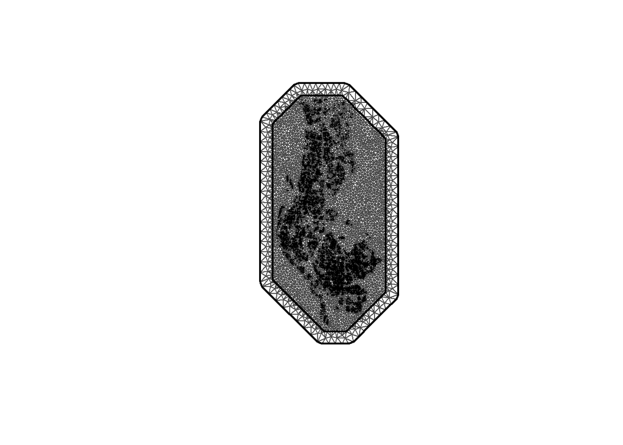

```r
# MESH VISUALIZATION

plot(mesh, asp = 1, main = "INLA SPDE Mesh - Pinellas County")
points(mesh_coords, pch = 16, cex = 0.1)
```

# 9. Define Matern SPDE model

```r
# 9. MATERN SPDE

spde <- inla.spde2.pcmatern(
  mesh = mesh,
  # Matern smoothness: alpha = 2 is the common Matern SPDE construction.
  alpha = 2,
  # PC prior: P(range < 1000 m) = 0.5
  prior.range = c(1000, 0.5),
  # PC prior: P(sigma > 1) = 0.5
  prior.sigma = c(1, 0.5),
  constr = TRUE
)

spde_summary <- tibble(
  Metric = "SPDE latent nodes",
  Value = spde$n.spde
)

knitr::kable(spde_summary, caption = "SPDE Model Summary")
```

SPDE Model Summary

| Metric | Value |
| --- | --- |
| SPDE latent nodes | 8779 |

# 10. Create SPDE projection matrix

```r
# 10. SPDE PROJECTION MATRIX

A_spde <- inla.spde.make.A(
  mesh = mesh,
  loc = projected_coords
)

projection_summary <- tibble(
  Metric = c("Projection matrix rows", "Projection matrix columns", "SPDE latent nodes"),
  Value = c(nrow(A_spde), ncol(A_spde), spde$n.spde)
)

knitr::kable(
  projection_summary,
  caption = "SPDE Projection Matrix Dimensions"
)
```

SPDE Projection Matrix Dimensions

| Metric | Value |
| --- | --- |
| Projection matrix rows | 245477 |
| Projection matrix columns | 8779 |
| SPDE latent nodes | 8779 |

# 11. Create INLA spatial index

```r
# 11. SPATIAL INDEX

spatial_index <- inla.spde.make.index(name = "spatial_field", n.spde = spde$n.spde)
```

# 12. Create INLA model stack

```r
# 12. INLA STACK

# Fixed effects
fixed_effects <- data.frame(
  intercept = 1,
  sale_year_c = bayes_data$sale_year_c,
  frontage_group = bayes_data$frontage_group,
  seawall_group = bayes_data$seawall_group,
  cccl_distance_b = bayes_data$cccl_distance_b,
  tb_distance_b = bayes_data$tb_distance_b,
  quality_group = bayes_data$quality_group,
  heated_area_b = bayes_data$heated_area_b,
  acreage_b = bayes_data$acreage_b,
  barrier_municipality = bayes_data$barrier_municipality,
  stories_group = bayes_data$stories_group,
  foundation_group = bayes_data$foundation_group,
  city_id = bayes_data$city_id
)

# Create stack
spatial_stack <- inla.stack(
  tag = "est",
  data = list(y = bayes_data$log_price),
  A = list(1, A_spde),
  effects = list(fixed_effects, spatial_index),
  remove.unused = FALSE
)

stack_data <- inla.stack.data(spatial_stack)

stack_summary <- tibble(
  Metric = "Stack observations",
  Value = length(stack_data$y)
)

knitr::kable(
  stack_summary,
  caption = "INLA Stack Summary"
)
```

INLA Stack Summary

| Metric | Value |
| --- | --- |
| Stack observations | 245477 |

# 13. Primary INLA spatial model

```r
# 13. PRIMARY INLA SPATIAL MODEL

spatial_formula <- y ~
  0 +
  intercept +
  sale_year_c +
  frontage_group +
  seawall_group +
  cccl_distance_b +
  tb_distance_b +
  quality_group +
  heated_area_b +
  acreage_b +
  barrier_municipality +
  stories_group +
  foundation_group +
  f(city_id, model = "iid") +
  f(spatial_field, model = spde)

inla_spatial <- inla(
  formula = spatial_formula,
  family = "gaussian",
  data = inla.stack.data(spatial_stack),
  control.predictor = list(
    A = inla.stack.A(spatial_stack),
    compute = TRUE,
    link = 1
  ),
  control.compute = list(
    dic = TRUE,
    waic = TRUE,
    cpo = TRUE,
    return.marginals.predictor = TRUE,
    config = TRUE
  ),
  control.inla = list(
    strategy = "simplified.laplace"
  ),
  verbose = TRUE
)

summary(inla_spatial)
```

```
Time used:
    Pre = 1.68, Running = 51.4, Post = 21.4, Total = 74.4
Fixed effects:
                              mean     sd 0.025quant 0.5quant 0.975quant   mode
intercept                    9.375 14.142    -18.356    9.375     37.106  9.375
sale_year_c                 -0.004  0.000     -0.004   -0.004     -0.003 -0.004
frontage_groupNone           2.184 14.142    -25.547    2.184     29.915  2.184
frontage_groupLake           2.233 14.142    -25.498    2.233     29.964  2.233
frontage_groupBay            2.516 14.142    -25.215    2.516     30.247  2.516
frontage_groupOther          2.442 14.142    -25.289    2.442     30.173  2.442
seawall_groupYes             0.160  0.012      0.136    0.160      0.184  0.160
cccl_distance_b              0.002  0.029     -0.055    0.002      0.058  0.002
tb_distance_b                0.070  0.031      0.009    0.070      0.132  0.070
quality_groupFair           -0.185  0.006     -0.196   -0.185     -0.174 -0.185
quality_groupAbove Average   0.158  0.006      0.146    0.158      0.171  0.158
heated_area_b                0.203  0.002      0.199    0.203      0.208  0.203
acreage_b                    0.028  0.002      0.025    0.028      0.031  0.028
barrier_municipalityBarrier  0.338  0.118      0.109    0.338      0.573  0.337
stories_group2              -0.022  0.006     -0.033   -0.022     -0.011 -0.022
stories_group3+             -0.057  0.014     -0.085   -0.057     -0.029 -0.057
foundation_groupYes          0.053  0.007      0.039    0.053      0.066  0.053
                            kld
intercept                     0
sale_year_c                   0
frontage_groupNone            0
frontage_groupLake            0
frontage_groupBay             0
frontage_groupOther           0
seawall_groupYes              0
cccl_distance_b               0
tb_distance_b                 0
quality_groupFair             0
quality_groupAbove Average    0
heated_area_b                 0
acreage_b                     0
barrier_municipalityBarrier   0
stories_group2                0
stories_group3+               0
foundation_groupYes           0

```

[output cut: 13 more lines]

```
Precision for city_id                       17.300    9.653
Range for spatial_field                   1677.316 1551.204
Stdev for spatial_field                      0.419    0.395

Deviance Information Criterion (DIC) ...............: 460305.54
Deviance Information Criterion (DIC, saturated) ....: 248949.05
Effective number of parameters .....................: 3457.99

Watanabe-Akaike information criterion (WAIC) ...: 457200.59
Effective number of parameters .................: 3607.72

Marginal log-Likelihood:  -232582.49
CPO, PIT is computed
Posterior summaries for the linear predictor and the fitted values are computed
(Posterior marginals needs also 'control.compute=list(return.marginals.predictor=TRUE)')
```

Bayesian hierarchical spatial regression estimated using the Integrated Nested Laplace Approximation (INLA)

## Mathematical Specification of the Bayesian Spatial Hedonic Model

The primary model estimates the relationship between housing prices and structural, locational, and geographic characteristics while accounting for municipality-level variation and spatial dependence.

The response variable is the natural logarithm of the adjusted sale price:

$$Y_i = \log(\text{adj\_price}_i)$$

The observation model is:

$$Y_i \mid \eta_i,\tau_\epsilon
\sim
\mathcal{N}(\eta_i,\tau_\epsilon^{-1})$$

The linear predictor is:

$$\begin{aligned}
\eta_i =\;&
\beta_0
+ \beta_1 \text{SaleYear}_i
+ \boldsymbol{\beta}_2^\top \text{Frontage}_i
+ \beta_3 \text{Seawall}_i \\
&+ \beta_4 \text{CCCLDistance}_i
+ \beta_5 \text{TBDistance}_i
+ \boldsymbol{\beta}_6^\top \text{Quality}_i \\
&+ \beta_7 \text{HeatedArea}_i
+ \beta_8 \text{Acreage}_i
+ \beta_9 \text{BarrierMunicipality}_i \\
&+ \boldsymbol{\beta}_{10}^\top \text{Stories}_i
+ \boldsymbol{\beta}_{11}^\top \text{Foundation}_i \\
&+ u_{c(i)}
+ w(\mathbf{s}_i)
\end{aligned}$$

where:

The municipality-level random effects are modeled as:

$$u_j \overset{\text{iid}}{\sim}
\mathcal{N}(0,\sigma^2_{\text{city}})$$

The spatial random effect is modeled as a Matérn Gaussian random field:

$$w(\mathbf{s}) \sim
\text{Matérn}(\sigma^2_{\text{spatial}},\rho,\nu)$$

The Matérn spatial field is represented computationally using the Stochastic Partial Differential Equation (SPDE) approach:

$$(\kappa^2-\Delta)^{\alpha/2}
\left(\tau_{\text{SPDE}}w(\mathbf{s})\right)
=
\mathcal{W}(\mathbf{s})$$

$$\alpha=2,\qquad d=2,\qquad
\nu=\alpha-\frac{d}{2}=1$$

$$\rho=\frac{\sqrt{8\nu}}{\kappa}$$

The SPDE model uses penalized-complexity (PC) priors for the spatial range and marginal standard deviation:

$$P(\rho < 1000)=0.5$$

$$P(\sigma_{\text{spatial}}>1)=0.5$$

These priors correspond to the INLA specification `prior.range = c(1000, 0.5)` and `prior.sigma = c(1, 0.5)`, assuming the projected coordinate system uses meters.

The complete model is estimated using Integrated Nested Laplace Approximations (INLA), which provides approximate Bayesian inference for the fixed effects, municipality-level random effects, spatial field, and model hyperparameters.

```r
# MODEL OUTPUT: COEFFICIENTS, RANDOM EFFECTS, PRIORS, AND FIT

# 1. Fixed-effect coefficient estimates
fixed_effect_output <- inla_spatial$summary.fixed

print("FIXED EFFECT COEFFICIENTS")
```

```
[1] "FIXED EFFECT COEFFICIENTS"
```

```r
print(fixed_effect_output)
```

```
                                    mean           sd    0.025quant
intercept                    9.374883002 1.414202e+01 -18.356216016
sale_year_c                 -0.003650094 2.556805e-04  -0.004151458
frontage_groupNone           2.184065756 1.414194e+01 -25.546885556
frontage_groupLake           2.233352524 1.414195e+01 -25.497601741
frontage_groupBay            2.515819012 1.414195e+01 -25.215139860
frontage_groupOther          2.442256953 1.414195e+01 -25.288696178
seawall_groupYes             0.160106865 1.235523e-02   0.135879159
cccl_distance_b              0.001790959 2.876061e-02  -0.055164896
tb_distance_b                0.070474068 3.113753e-02   0.009336900
quality_groupFair           -0.185049639 5.810283e-03  -0.196442637
quality_groupAbove Average   0.158355190 6.491431e-03   0.145625348
heated_area_b                0.203403385 2.488130e-03   0.198523753
acreage_b                    0.028033238 1.692334e-03   0.024714954
barrier_municipalityBarrier  0.338457169 1.178452e-01   0.108871136
stories_group2              -0.022294843 5.538528e-03  -0.033155170
stories_group3+             -0.057036817 1.437416e-02  -0.085222928
foundation_groupYes          0.052779499 6.852998e-03   0.039341345
                                0.5quant   0.975quant         mode          kld
intercept                    9.374882941 37.105982367  9.374882941 5.526800e-11
sale_year_c                 -0.003650094 -0.003148729 -0.003650094 5.465231e-11
frontage_groupNone           2.184065755 29.915017075  2.184065755 5.526796e-11
frontage_groupLake           2.233352523 29.964306794  2.233352523 5.526802e-11
frontage_groupBay            2.515819016 30.246777861  2.515819016 5.526802e-11
frontage_groupOther          2.442256956 30.173210064  2.442256956 5.526791e-11
seawall_groupYes             0.160106972  0.184333963  0.160106972 5.445558e-11
cccl_distance_b              0.001974702  0.057716138  0.001979126 1.016966e-08
tb_distance_b                0.070487012  0.131533266  0.070485851 6.155507e-10
quality_groupFair           -0.185049780 -0.173655844 -0.185049781 5.498146e-11
quality_groupAbove Average   0.158355461  0.171083485  0.158355463 5.479288e-11
heated_area_b                0.203403626  0.208281651  0.203403629 6.136557e-11
acreage_b                    0.028033159  0.031351977  0.028033158 5.317823e-11
barrier_municipalityBarrier  0.337537212  0.573038703  0.337495299 4.053801e-08
stories_group2              -0.022294909 -0.011434143 -0.022294909 5.469340e-11
stories_group3+             -0.057036890 -0.028850288 -0.057036891 5.460474e-11
foundation_groupYes          0.052779532  0.066217466  0.052779532 5.463035e-11
```

```r
# 2. Municipality random effects
municipality_output <- inla_spatial$summary.random$city_id

print("MUNICIPALITY RANDOM EFFECTS")
```

```
[1] "MUNICIPALITY RANDOM EFFECTS"
```

```r
print(municipality_output)
```

```
   ID        mean         sd   0.025quant    0.5quant  0.975quant        mode
1   1  0.32536139 0.08658814  0.157269562  0.32463827  0.49746370  0.32461358
2   2 -0.28646486 0.13746079 -0.555256589 -0.28715206 -0.01368353 -0.28712023
3   3  0.10100318 0.07665480 -0.049154964  0.10076979  0.25243418  0.10075846
4   4  0.56215267 0.14537880  0.286084899  0.55904892  0.85567788  0.55893099
5   5 -0.08680159 0.06218447 -0.210653217 -0.08639071  0.03480141 -0.08638188
6   6  0.06087632 0.10424313 -0.145101370  0.06128589  0.26454727  0.06129027
7   7 -0.06374246 0.07026289 -0.203568728 -0.06320205  0.07307592 -0.06319286
8   8  0.01425317 0.07584499 -0.136769513  0.01491630  0.16159186  0.01493255
9   9  0.13164154 0.12498339 -0.111942537  0.13080602  0.37984363  0.13078179
10 10 -0.05408802 0.14378781 -0.339996177 -0.05296738  0.22569040 -0.05291916
11 11 -0.20148938 0.07859387 -0.358517491 -0.20056010 -0.04961619 -0.20053044
12 12  0.02917954 0.06183759 -0.093857482  0.02953453  0.15028269  0.02954349
13 13 -0.10427166 0.13536572 -0.372805042 -0.10344643  0.15976486 -0.10340685
14 14  0.06757419 0.13357942 -0.196638973  0.06800840  0.32932140  0.06800294
```

[output cut: 41 more lines]

```r
# 3. Spatial random field summary
spatial_output <- inla_spatial$summary.random$spatial_field

print("SPATIAL RANDOM FIELD")
```

```
[1] "SPATIAL RANDOM FIELD"
```

```r
print(spatial_output)
```

```
       ID          mean         sd    0.025quant      0.5quant    0.975quant
1       0  2.244309e-02 0.35950622 -6.826310e-01  2.242805e-02  7.276115e-01
2       1  3.526748e-03 0.40088829 -7.829774e-01  3.490640e-03  7.902373e-01
3       2  1.116567e-03 0.40628237 -7.959238e-01  1.105958e-03  7.982176e-01
4       3 -2.229771e-05 0.41254905 -8.093142e-01 -2.218937e-05  8.092690e-01
5       4  3.738656e-02 0.39633531 -7.398226e-01  3.726734e-02  8.152769e-01
6       5  5.225979e-02 0.39963716 -7.313296e-01  5.213743e-02  8.365485e-01
7       6 -1.487377e-05 0.41007803 -8.044676e-01 -1.486213e-05  8.044378e-01
8       7  8.929365e-05 0.41405561 -8.121609e-01  8.816812e-05  8.123460e-01
9       8  7.356096e-03 0.41912673 -8.147814e-01  7.315071e-03  8.297285e-01
10      9 -3.074512e-06 0.41829770 -8.206416e-01 -3.178442e-06  8.206360e-01
11     10  6.352944e-02 0.41579325 -7.514728e-01  6.328165e-02  8.799461e-01
12     11  1.207984e-01 0.41239020 -6.873385e-01  1.204988e-01  9.306433e-01
13     12  2.666644e-01 0.38667734 -4.902987e-01  2.661179e-01  1.026740e+00
14     13  3.881441e-04 0.41809945 -8.198505e-01  3.852262e-04  8.206434e-01
```

[output cut: 17545 more lines]

```r
# 4. Hyperparameter estimates
hyperparameter_output <- inla_spatial$summary.hyperpar

print("MODEL HYPERPARAMETERS")
```

```
[1] "MODEL HYPERPARAMETERS"
```

```r
print(hyperparameter_output)
```

```
                                                mean           sd   0.025quant
Precision for the Gaussian observations    2.6560662  0.007684086    2.6407232
Precision for city_id                     10.3383394  3.359202347    4.4906999
Range for spatial_field                 1546.8855543 66.643033328 1415.1355003
Stdev for spatial_field                    0.3951115  0.011761252    0.3724756
                                            0.5quant   0.975quant         mode
Precision for the Gaussian observations    2.6561390    2.6709773    2.6564733
Precision for city_id                     10.0844725   17.2999829    9.6527522
Range for spatial_field                 1547.0407286 1677.3160816 1551.2038509
Stdev for spatial_field                    0.3949311    0.4187859    0.3945595
```

```r
# 5. Model fit statistics
model_fit_output <- data.frame(
  DIC = inla_spatial$dic$dic,
  WAIC = inla_spatial$waic$waic,
  log_marginal_likelihood = inla_spatial$mlik[1]
)

print("MODEL FIT STATISTICS")
```

```
[1] "MODEL FIT STATISTICS"
```

```r
print(model_fit_output)
```

```
       DIC     WAIC log_marginal_likelihood
1 460305.5 457200.6               -232584.8
```

```r
# 6. Save all model output tables
write.csv(
  fixed_effect_output,
  "fixed_effect_coefficients.csv"
)

write.csv(
  municipality_output,
  "municipality_random_effects.csv"
)

write.csv(
  spatial_output,
  "spatial_random_effects.csv"
)

write.csv(
  hyperparameter_output,
  "model_hyperparameters.csv"
)

write.csv(
  model_fit_output,
  "model_fit_statistics.csv",
  row.names = FALSE
)
```

# 14. Primary model fixed effects

```r
# 14. FIXED EFFECTS
spatial_fixed_effects <- inla_spatial$summary.fixed
spatial_fixed_effects
```

|  | mean | sd | 0.025quant | 0.5quant | 0.975quant | mode | kld |
| --- | --- | --- | --- | --- | --- | --- | --- |
| intercept | 9.374883002 | 1.414202e+01 | -18.356216016 | 9.374882941 | 37.105982367 | 9.374882941 | 5.526800e-11 |
| sale_year_c | -0.003650094 | 2.556805e-04 | -0.004151458 | -0.003650094 | -0.003148729 | -0.003650094 | 5.465231e-11 |
| frontage_groupNone | 2.184065756 | 1.414194e+01 | -25.546885556 | 2.184065755 | 29.915017075 | 2.184065755 | 5.526796e-11 |
| frontage_groupLake | 2.233352524 | 1.414195e+01 | -25.497601741 | 2.233352523 | 29.964306794 | 2.233352523 | 5.526802e-11 |
| frontage_groupBay | 2.515819012 | 1.414195e+01 | -25.215139860 | 2.515819016 | 30.246777861 | 2.515819016 | 5.526802e-11 |
| frontage_groupOther | 2.442256953 | 1.414195e+01 | -25.288696178 | 2.442256956 | 30.173210064 | 2.442256956 | 5.526791e-11 |
| seawall_groupYes | 0.160106865 | 1.235523e-02 | 0.135879159 | 0.160106972 | 0.184333963 | 0.160106972 | 5.445558e-11 |
| cccl_distance_b | 0.001790959 | 2.876061e-02 | -0.055164896 | 0.001974702 | 0.057716138 | 0.001979126 | 1.016966e-08 |
| tb_distance_b | 0.070474068 | 3.113753e-02 | 0.009336900 | 0.070487012 | 0.131533266 | 0.070485851 | 6.155507e-10 |
| quality_groupFair | -0.185049639 | 5.810283e-03 | -0.196442637 | -0.185049780 | -0.173655844 | -0.185049781 | 5.498146e-11 |

[output cut: 7 more lines]

```r
# FIXED EFFECTS: CLEAN TABLE

spatial_fixed_effects_clean <-
  spatial_fixed_effects %>%

  rownames_to_column(
    var = "Term"
  ) %>%

  select(
    Term,
    mean,
    sd,
    `0.025quant`,
    `0.5quant`,
    `0.975quant`
  )

spatial_fixed_effects_clean
```

| Term | mean | sd | 0.025quant | 0.5quant | 0.975quant |
| --- | --- | --- | --- | --- | --- |
| intercept | 9.374883002 | 1.414202e+01 | -18.356216016 | 9.374882941 | 37.105982367 |
| sale_year_c | -0.003650094 | 2.556805e-04 | -0.004151458 | -0.003650094 | -0.003148729 |
| frontage_groupNone | 2.184065756 | 1.414194e+01 | -25.546885556 | 2.184065755 | 29.915017075 |
| frontage_groupLake | 2.233352524 | 1.414195e+01 | -25.497601741 | 2.233352523 | 29.964306794 |
| frontage_groupBay | 2.515819012 | 1.414195e+01 | -25.215139860 | 2.515819016 | 30.246777861 |
| frontage_groupOther | 2.442256953 | 1.414195e+01 | -25.288696178 | 2.442256956 | 30.173210064 |
| seawall_groupYes | 0.160106865 | 1.235523e-02 | 0.135879159 | 0.160106972 | 0.184333963 |
| cccl_distance_b | 0.001790959 | 2.876061e-02 | -0.055164896 | 0.001974702 | 0.057716138 |
| tb_distance_b | 0.070474068 | 3.113753e-02 | 0.009336900 | 0.070487012 | 0.131533266 |
| quality_groupFair | -0.185049639 | 5.810283e-03 | -0.196442637 | -0.185049780 | -0.173655844 |

[output cut: 7 more lines]

# 15. Municipality random effects

```r
# 15. MUNICIPALITY RANDOM EFFECTS
municipality_effects <-inla_spatial$summary.random$city_id
municipality_effects
```

| ID | mean | sd | 0.025quant | 0.5quant | 0.975quant | mode | kld |
| --- | --- | --- | --- | --- | --- | --- | --- |
| 1 | 0.32536139 | 0.08658814 | 0.157269562 | 0.32463827 | 0.49746370 | 0.32461358 | 2.111662e-08 |
| 2 | -0.28646486 | 0.13746079 | -0.555256589 | -0.28715206 | -0.01368353 | -0.28712023 | 3.406270e-08 |
| 3 | 0.10100318 | 0.07665480 | -0.049154964 | 0.10076979 | 0.25243418 | 0.10075846 | 1.966533e-08 |
| 4 | 0.56215267 | 0.14537880 | 0.286084899 | 0.55904892 | 0.85567788 | 0.55893099 | 1.120019e-07 |
| 5 | -0.08680159 | 0.06218447 | -0.210653217 | -0.08639071 | 0.03480141 | -0.08638188 | 6.030077e-08 |
| 6 | 0.06087632 | 0.10424313 | -0.145101370 | 0.06128589 | 0.26454727 | 0.06129027 | 1.016553e-08 |
| 7 | -0.06374246 | 0.07026289 | -0.203568728 | -0.06320205 | 0.07307592 | -0.06319286 | 3.664625e-08 |
| 8 | 0.01425317 | 0.07584499 | -0.136769513 | 0.01491630 | 0.16159186 | 0.01493255 | 3.161191e-08 |
| 9 | 0.13164154 | 0.12498339 | -0.111942537 | 0.13080602 | 0.37984363 | 0.13078179 | 2.615859e-08 |
| 10 | -0.05408802 | 0.14378781 | -0.339996177 | -0.05296738 | 0.22569040 | -0.05291916 | 2.689877e-08 |

[output cut: 17 more lines]

# 16. Spatial random effects

```r
# 16. SPATIAL RANDOM FIELD
spatial_field_summary <- inla_spatial$summary.random$spatial_field
head(spatial_field_summary)
```

|  | ID | mean | sd | 0.025quant | 0.5quant | 0.975quant | mode | kld |
| --- | --- | --- | --- | --- | --- | --- | --- | --- |
| 1 | 0 | 2.244309e-02 | 0.3595062 | -0.6826310 | 2.242805e-02 | 0.7276115 | 2.243047e-02 | 1.983131e-11 |
| 2 | 1 | 3.526748e-03 | 0.4008883 | -0.7829774 | 3.490640e-03 | 0.7902373 | 3.490705e-03 | 6.016819e-10 |
| 3 | 2 | 1.116567e-03 | 0.4062824 | -0.7959238 | 1.105958e-03 | 0.7982176 | 1.105966e-03 | 2.967241e-10 |
| 4 | 3 | -2.229771e-05 | 0.4125491 | -0.8093142 | -2.218937e-05 | 0.8092690 | -2.218954e-05 | 1.637989e-10 |
| 5 | 4 | 3.738656e-02 | 0.3963353 | -0.7398226 | 3.726734e-02 | 0.8152769 | 3.726746e-02 | 3.047179e-10 |
| 6 | 5 | 5.225979e-02 | 0.3996372 | -0.7313296 | 5.213743e-02 | 0.8365485 | 5.213772e-02 | 1.513738e-10 |

# 17. Spatial hyperparameters

```r
# 17. SPATIAL HYPERPARAMETERS

spatial_hyperparameters <- inla_spatial$summary.hyperpar
spatial_hyperparameters
```

|  | mean | sd | 0.025quant | 0.5quant | 0.975quant | mode |
| --- | --- | --- | --- | --- | --- | --- |
| Precision for the Gaussian observations | 2.6560662 | 0.007684086 | 2.6407232 | 2.6561390 | 2.6709773 | 2.6564733 |
| Precision for city_id | 10.3383394 | 3.359202347 | 4.4906999 | 10.0844725 | 17.2999829 | 9.6527522 |
| Range for spatial_field | 1546.8855543 | 66.643033328 | 1415.1355003 | 1547.0407286 | 1677.3160816 | 1551.2038509 |
| Stdev for spatial_field | 0.3951115 | 0.011761252 | 0.3724756 | 0.3949311 | 0.4187859 | 0.3945595 |

# 18. Model fit statistics

```r
# 18. MODEL FIT STATISTICS
spatial_model_fit <- tibble(Model = "INLA spatial SPDE", N = nrow(bayes_data), DIC = inla_spatial$dic$dic, WAIC = inla_spatial$waic$waic)
spatial_model_fit
```

| Model | N | DIC | WAIC |
| --- | --- | --- | --- |
| INLA spatial SPDE | 245477 | 460305.5 | 457200.6 |

# 19. Compare OLS, municipality, and spatial models

```r
# 19. MODEL COMPARISON

model_comparison <- tibble(
  Model = c("OLS hedonic baseline", "INLA municipality", "INLA spatial SPDE"),
  N = c(nobs(ols_model), nrow(bayes_data), nrow(bayes_data)),
  DIC = c(NA_real_, inla_city$dic$dic, inla_spatial$dic$dic),
  WAIC = c(NA_real_, inla_city$waic$waic, inla_spatial$waic$waic),
  R_squared = c(summary(ols_model)$r.squared, NA_real_, NA_real_)
)

model_comparison
```

| Model | N | DIC | WAIC | R_squared |
| --- | --- | --- | --- | --- |
| OLS hedonic baseline | 245477 | NA | NA | 0.4019507 |
| INLA municipality | 245477 | 506325.9 | 503197.2 | NA |
| INLA spatial SPDE | 245477 | 460305.5 | 457200.6 | NA |

# 20. Extract fitted values

```r
# 20. FITTED VALUES

# Extract fitted values from INLA
fitted_summary <- inla_spatial$summary.fitted.values

# Identify observed-data rows
estimation_index <- inla.stack.index(spatial_stack, tag = "est")$data

# Extract fitted values for observed observations only
observed_fitted <- fitted_summary$mean[estimation_index]

# Verify dimensions
if (length(observed_fitted) != nrow(bayes_data)) {
  stop(paste0(
    "ERROR: Fitted values do not match bayes_data. ",
    "Fitted values: ", length(observed_fitted),
    "; Observations: ", nrow(bayes_data)
  ))
}

# Assign fitted values
bayes_data$inla_fitted <- observed_fitted

# Calculate residuals
bayes_data$inla_residual <- bayes_data$log_price - bayes_data$inla_fitted

# Summary statistics
fitted_value_summary <- tibble(
  Statistic = c("Total INLA fitted values", "Observed-data stack rows", "Bayesian dataset rows"),
  Value = c(length(fitted_summary$mean), length(estimation_index), nrow(bayes_data))
)

print(fitted_value_summary)
```

```
# A tibble: 3 × 2
  Statistic                 Value
  <chr>                     <int>
1 Total INLA fitted values 480659
2 Observed-data stack rows 245477
3 Bayesian dataset rows    245477
```

```r
model_value_summary <- tibble(
  Variable = c("Fitted values", "Residuals"),
  Minimum = c(min(bayes_data$inla_fitted), min(bayes_data$inla_residual)),
  Mean = c(mean(bayes_data$inla_fitted), mean(bayes_data$inla_residual)),
  Median = c(median(bayes_data$inla_fitted), median(bayes_data$inla_residual)),
  Maximum = c(max(bayes_data$inla_fitted), max(bayes_data$inla_residual))
)

print(model_value_summary)
```

```
# A tibble: 2 × 5
  Variable      Minimum          Mean Median Maximum
  <chr>           <dbl>         <dbl>  <dbl>   <dbl>
1 Fitted values    8.96 11.3          11.2     17.7
2 Residuals       -7.73  0.0000000125  0.118    4.67
```

# 21. INLA prediction accuracy

```r
# 21. PREDICTION ACCURACY


inla_rmse <-
  sqrt(
    mean(
      bayes_data$inla_residual^2,
      na.rm = TRUE
    )
  )

inla_mae <-
  mean(
    abs(
      bayes_data$inla_residual
    ),
    na.rm = TRUE
  )

inla_r2 <-
  1 -

  sum(
    bayes_data$inla_residual^2,
    na.rm = TRUE
  ) /

  sum(
    (
      bayes_data$log_price -
        mean(
          bayes_data$log_price,
          na.rm = TRUE
        )
    )^2,

    na.rm = TRUE
  )

inla_accuracy <-
  tibble(

    Model =
      "INLA spatial SPDE",

    N =
      nrow(bayes_data),

    RMSE =
      inla_rmse,

    MAE =
      inla_mae,

    R_squared =
      inla_r2
  )

inla_accuracy
```

| Model | N | RMSE | MAE | R_squared |
| --- | --- | --- | --- | --- |
| INLA spatial SPDE | 245477 | 0.609266 | 0.3842009 | 0.5341746 |

# 22. Residual distribution

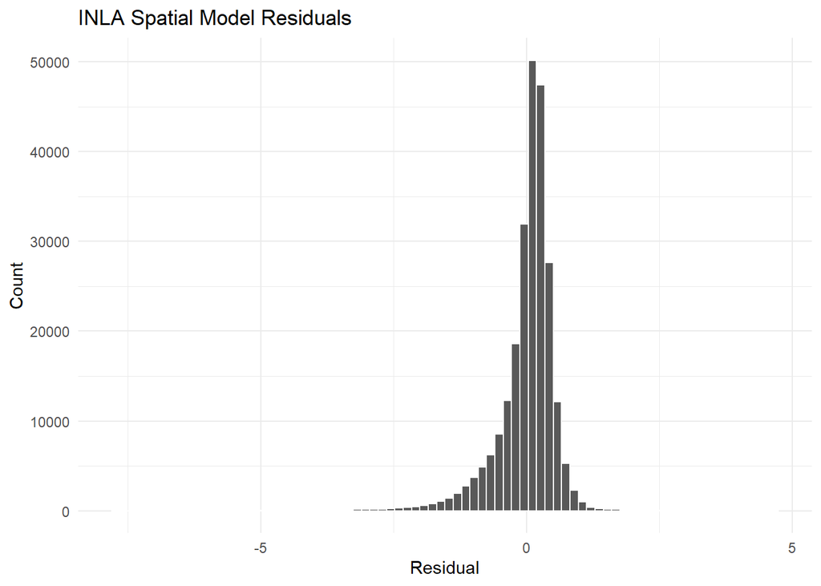

```r
# 22. RESIDUAL DISTRIBUTION


ggplot(
  bayes_data,
  aes(
    x = inla_residual
  )
) +

  geom_histogram(
    bins = 80,
    color = "white"
  ) +

  labs(
    title =
      "INLA Spatial Model Residuals",
    x =
      "Residual",
    y =
      "Count"
  ) +

  theme_minimal()
```

# 23. Residuals versus fitted values

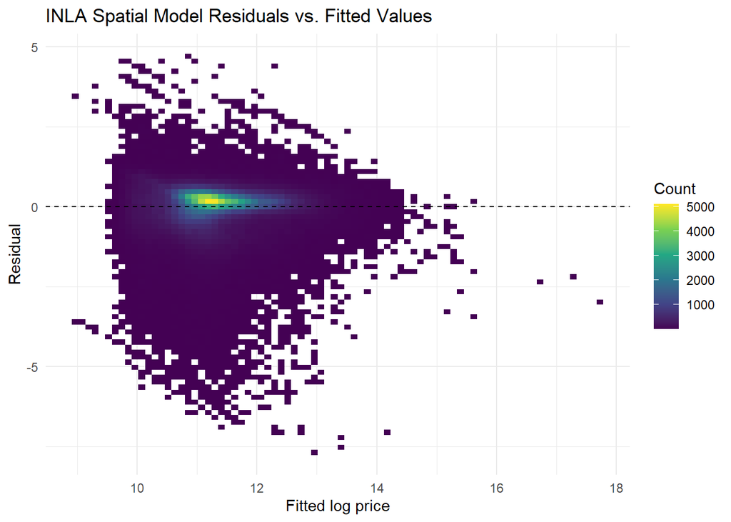

```r
# 23. RESIDUALS VS FITTED


ggplot(
  bayes_data,
  aes(
    x = inla_fitted,
    y = inla_residual
  )
) +

  geom_bin2d(
    bins = 80
  ) +

  scale_fill_viridis_c() +

  geom_hline(
    yintercept = 0,
    linetype = "dashed"
  ) +

  labs(
    title =
      "INLA Spatial Model Residuals vs. Fitted Values",
    x =
      "Fitted log price",
    y =
      "Residual",
    fill =
      "Count"
  ) +

  theme_minimal()
```

# 24. Spatial residual map

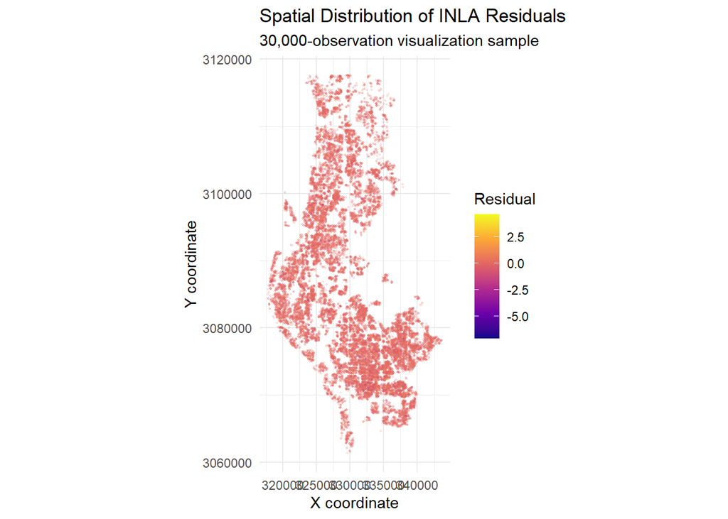

```r
# 24. SPATIAL RESIDUAL MAP


set.seed(12345)

residual_map_n <-
  min(
    30000L,
    nrow(bayes_data)
  )

residual_map_id <-
  sample(
    seq_len(
      nrow(bayes_data)
    ),
    size =
      residual_map_n
  )

residual_map_data <-
  bayes_data[
    residual_map_id,
  ]

ggplot(
  residual_map_data,
  aes(
    x = x_coord,
    y = y_coord,
    color = inla_residual
  )
) +

  geom_point(
    alpha = 0.15,
    size = 0.3
  ) +

  scale_color_viridis_c(
    option = "plasma"
  ) +

  coord_equal() +

  labs(
    title =
      "Spatial Distribution of INLA Residuals",
    subtitle =
      "30,000-observation visualization sample",
    x =
      "X coordinate",
    y =
      "Y coordinate",
    color =
      "Residual"
  ) +

  theme_minimal()
```

# 25. Spatial field map

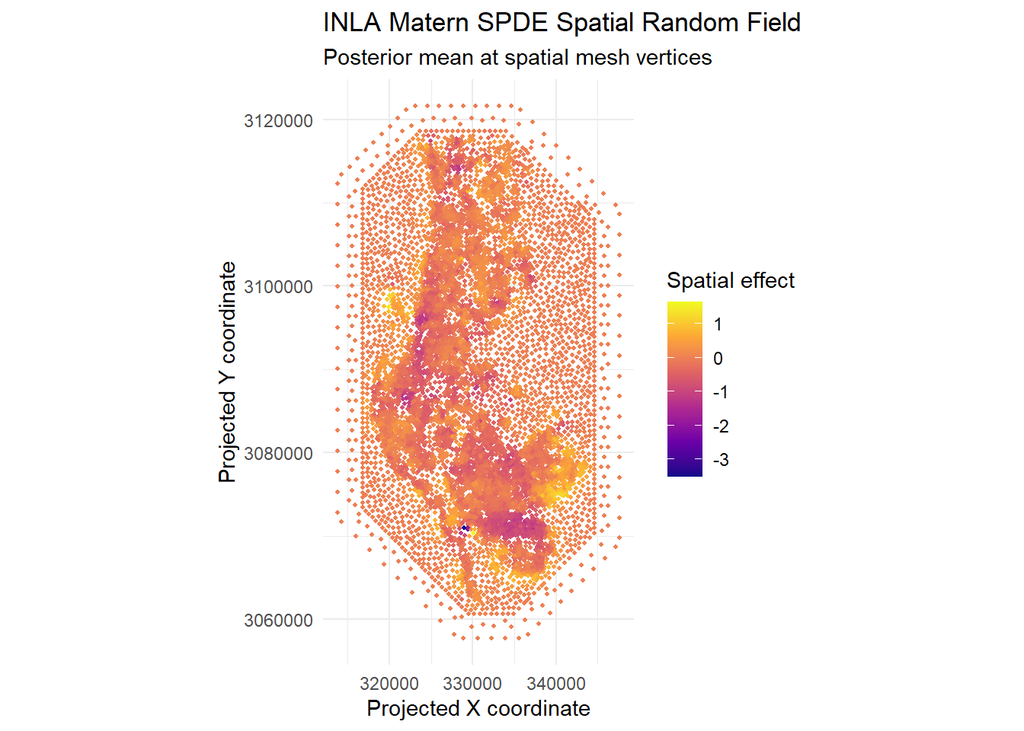

```r
# 25. SPATIAL RANDOM FIELD MAP



# The SPDE random effect is defined at mesh vertices.


mesh_field <-
  tibble(

    x =
      mesh$loc[, 1],

    y =
      mesh$loc[, 2],

    spatial_effect =
      spatial_field_summary$mean,

    spatial_lower =
      spatial_field_summary$`0.025quant`,

    spatial_upper =
      spatial_field_summary$`0.975quant`
  )

ggplot(
  mesh_field,
  aes(
    x = x,
    y = y,
    color = spatial_effect
  )
) +

  geom_point(
    size = 0.8
  ) +

  scale_color_viridis_c(
    option = "plasma"
  ) +

  coord_equal() +

  labs(
    title =
      "INLA Matern SPDE Spatial Random Field",
    subtitle =
      "Posterior mean at spatial mesh vertices",
    x =
      "Projected X coordinate",
    y =
      "Projected Y coordinate",
    color =
      "Spatial effect"
  ) +

  theme_minimal()
```

# 26. Spatial uncertainty map

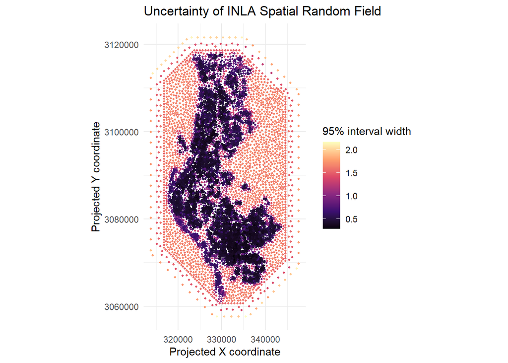

```r
# 26. SPATIAL EFFECT UNCERTAINTY


mesh_field <-
  mesh_field %>%

  mutate(
    spatial_sd =
      spatial_upper -
      spatial_lower
  )

ggplot(
  mesh_field,
  aes(
    x = x,
    y = y,
    color = spatial_sd
  )
) +

  geom_point(
    size = 0.8
  ) +

  scale_color_viridis_c(
    option = "magma"
  ) +

  coord_equal() +

  labs(
    title =
      "Uncertainty of INLA Spatial Random Field",
    x =
      "Projected X coordinate",
    y =
      "Projected Y coordinate",
    color =
      "95% interval width"
  ) +

  theme_minimal()
```

# 27. Observed versus fitted values

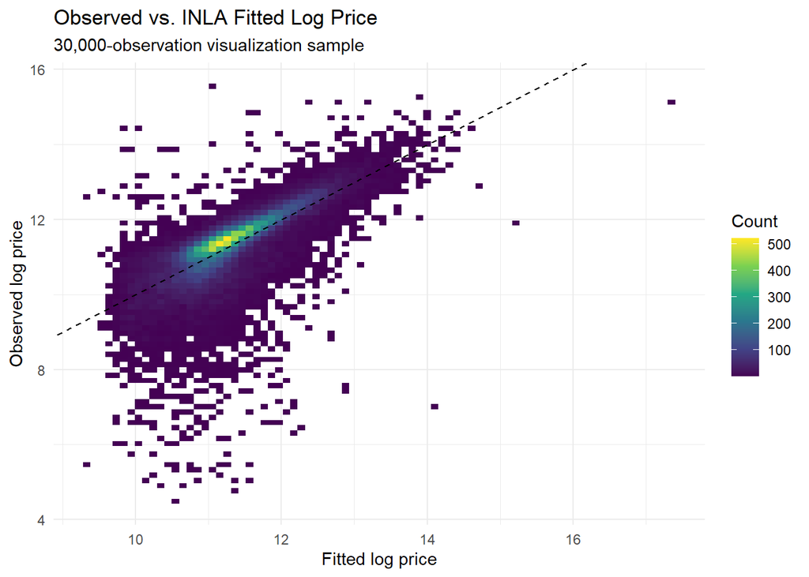

```r
# 27. OBSERVED VS FITTED


set.seed(12345)

fit_plot_n <-
  min(
    30000L,
    nrow(bayes_data)
  )

fit_plot_id <-
  sample(
    seq_len(
      nrow(bayes_data)
    ),
    size =
      fit_plot_n
  )

fit_plot_data <-
  bayes_data[
    fit_plot_id,
  ]

ggplot(
  fit_plot_data,
  aes(
    x = inla_fitted,
    y = log_price
  )
) +

  geom_bin2d(
    bins = 80
  ) +

  scale_fill_viridis_c() +

  geom_abline(
    slope = 1,
    intercept = 0,
    linetype = "dashed"
  ) +

  labs(
    title =
      "Observed vs. INLA Fitted Log Price",
    subtitle =
      "30,000-observation visualization sample",
    x =
      "Fitted log price",
    y =
      "Observed log price",
    fill =
      "Count"
  ) +

  theme_minimal()
```

# 28. Municipality effects plot

```r
# 28. MUNICIPALITY EFFECT PLOT


# Extract municipality random effects
city_effect_plot <-
  inla_spatial$summary.random$city_id %>%

  # INLA stores municipality IDs in the ID column
  mutate(
    city_id = as.integer(ID)
  ) %>%

  # Join municipality names
  left_join(
    bayes_data %>%
      select(
        city_id,
        site_city
      ) %>%
      distinct(),
    by = "city_id"
  ) %>%

  # Arrange by estimated municipality effect
  arrange(
    mean
  )

print(
  head(city_effect_plot)
)
```

```
  ID       mean         sd 0.025quant   0.5quant  0.975quant       mode
1 25 -0.3272566 0.09503336 -0.5176143 -0.3258836 -0.14460335 -0.3258502
2  2 -0.2864649 0.13746079 -0.5552566 -0.2871521 -0.01368353 -0.2871202
3 24 -0.2680707 0.06496690 -0.3987569 -0.2670754 -0.14277887 -0.2670280
4 19 -0.2507167 0.13725536 -0.5265986 -0.2484769  0.01287464 -0.2483722
5 17 -0.2418076 0.07473065 -0.3912098 -0.2409043 -0.09740902 -0.2408754
6 11 -0.2014894 0.07859387 -0.3585175 -0.2005601 -0.04961619 -0.2005304
           kld city_id        site_city
1 4.935360e-08      25   TARPON SPRINGS
2 3.406270e-08       2   BELLEAIR BEACH
3 7.260369e-08      24    ST PETERSBURG
4 6.220526e-08      19 REDINGTON SHORES
5 4.110238e-08      17    PINELLAS PARK
6 3.807411e-08      11     KENNETH CITY
```

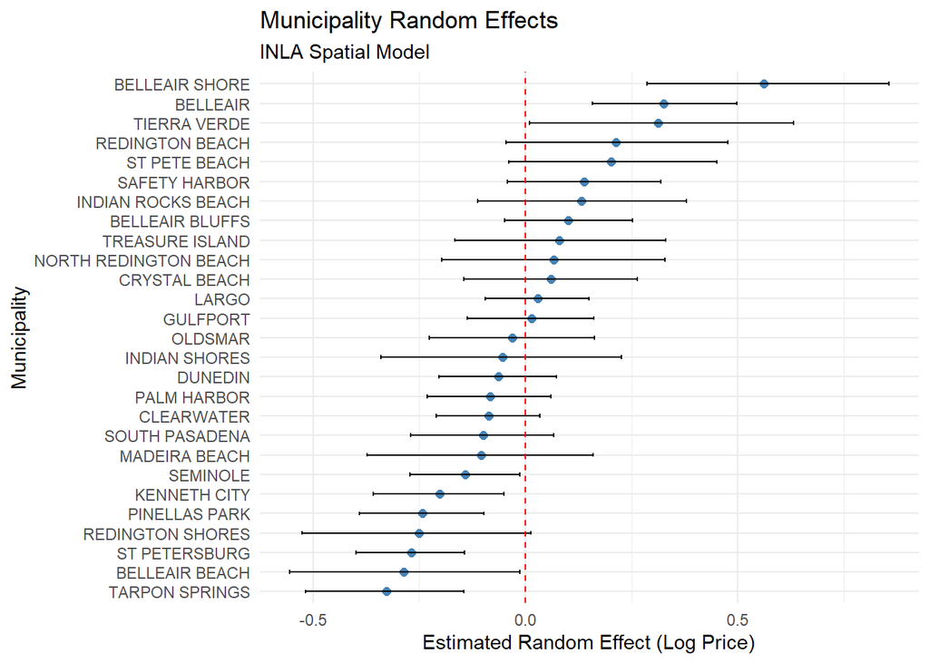

```r
# Check for unmatched municipality names
if (any(is.na(city_effect_plot$site_city))) {
  warning(
    "Some municipality IDs did not match municipality names."
  )
}

# Plot municipality random effects
ggplot(
  city_effect_plot,
  aes(
    x = reorder(site_city, mean),
    y = mean
  )
) +

  geom_point(
    size = 2,
    color = "steelblue"
  ) +

  geom_errorbar(
    aes(
      ymin = `0.025quant`,
      ymax = `0.975quant`
    ),
    width = 0.2
  ) +

  coord_flip() +

  geom_hline(
    yintercept = 0,
    linetype = "dashed",
    color = "red"
  ) +

  labs(
    title = "Municipality Random Effects",
    subtitle = "INLA Spatial Model",
    x = "Municipality",
    y = "Estimated Random Effect (Log Price)"
  ) +

  theme_minimal()
```

# 29. Save fitted models and objects

```r
# 29. SAVE MODELS AND OBJECTS
#saveRDS(ols_model, "pinellas_ols_inla_v1.rds")
#saveRDS(inla_city, "pinellas_inla_city_v1.rds")
#saveRDS(inla_spatial, "pinellas_inla_spatial_spde_v1.rds")
#saveRDS(mesh,"pinellas_inla_mesh_v1.rds")
#saveRDS(spde,"pinellas_inla_spde_v1.rds")
#saveRDS(model_data, "pinellas_model_data_v1.rds")
#saveRDS(bayes_data, "pinellas_bayes_data_v1.rds")
#saveRDS(model_comparison, "pinellas_model_comparison_v1.rds")
```

# 30. Final model summary table

```r
# 30. FINAL SUMMARY TABLE

final_summary <- tibble(Model = c("OLS Hedonic Baseline", "INLA Municipality", "INLA Spatial SPDE"),

    Observations = c(
      nobs(ols_model),
      nrow(bayes_data),
      nrow(bayes_data)
    ),

    R_squared = c(
      summary(
        ols_model
      )$r.squared,

      NA_real_,

      inla_r2
    ),

    RMSE = c(
      sqrt(
        mean(
          residuals(ols_model)^2
        )
      ),

      NA_real_,

      inla_rmse
    ),

    MAE = c(
      mean(
        abs(
          residuals(ols_model)
        )
      ),

      NA_real_,

      inla_mae
    ),

    DIC = c(
      NA_real_,
      inla_city$dic$dic,
      inla_spatial$dic$dic
    ),

    WAIC = c(
      NA_real_,
      inla_city$waic$waic,
      inla_spatial$waic$waic
    )
  )

final_summary
```

| Model | Observations | R_squared | RMSE | MAE | DIC | WAIC |
| --- | --- | --- | --- | --- | --- | --- |
| OLS Hedonic Baseline | 245477 | 0.4019507 | 0.6903413 | 0.4611369 | NA | NA |
| INLA Municipality | 245477 | NA | NA | NA | 506325.9 | 503197.2 |
| INLA Spatial SPDE | 245477 | 0.5341746 | 0.6092660 | 0.3842009 | 460305.5 | 457200.6 |